```python
# Librerias
import datetime
from datetime import datetime
import numpy as np
import pandas as pd
import scipy.stats as stats
import matplotlib.pyplot as plt
import random
import time
import seaborn as sns
%matplotlib inline
import matplotlib
import math
np.random.seed(123)
np.random.seed(0)
import plotly
plotly.tools.set_credentials_file(username='dianachav', api_key='wq86MyrntROmRpx2KOP4')
import plotly.plotly as py
import plotly.graph_objs as go

import seaborn as sns; sns.set()
sns.set(font_scale=1.4)
```

# Proyecto de Aplicación Profesional

## Optimización De Programas de Inversión para Intermediarios Financieros

### Integrantes:

### - Flores Juan Antonio

```python
lista = ['https://raw.githubusercontent.com/Dianachav/PAP_Spring_19/master/ETFS/iShares-Core-SP-500-ETF_fund.csv',
         'https://raw.githubusercontent.com/Dianachav/PAP_Spring_19/master/ETFS/iShares-Core-SP-Mid-Cap-ETF_fund.csv',
         'https://raw.githubusercontent.com/Dianachav/PAP_Spring_19/master/ETFS/iShares-Core-SP-Total-US-Stock-Market-ETF_fund.csv',
         'https://raw.githubusercontent.com/Dianachav/PAP_Spring_19/master/ETFS/iShares-Expanded-Tech-Sector-ETF_fund.csv', #nuevo
         'https://raw.githubusercontent.com/Dianachav/PAP_Spring_19/master/ETFS/iShares-Expanded-Tech-Software-Sector-ETF_fund.csv', #nuevo
         'https://raw.githubusercontent.com/Dianachav/PAP_Spring_19/master/ETFS/iShares-MSCI-ACWI-ETF_fund.csv',
         'https://raw.githubusercontent.com/Dianachav/PAP_Spring_19/master/ETFS/iShares-MSCI-EAFE-ETF_fund.csv',
         'https://raw.githubusercontent.com/Dianachav/PAP_Spring_19/master/ETFS/iShares-MSCI-Emerging-Markets-ETF_fund.csv',
         'https://raw.githubusercontent.com/Dianachav/PAP_Spring_19/master/ETFS/iShares-MSCI-Japan-ETF_fund.csv',
         'https://raw.githubusercontent.com/Dianachav/PAP_Spring_19/master/ETFS/iShares-MSCI-USA-ESG-Select-ETF_fund.csv',
         'https://raw.githubusercontent.com/Dianachav/PAP_Spring_19/master/ETFS/iShares-Nasdaq-Biotechnology-ETF_fund.csv',
         'https://raw.githubusercontent.com/Dianachav/PAP_Spring_19/master/ETFS/iShares-North-American-Tech-Multimedia-Networking-ETF_fund.csv',
         'https://raw.githubusercontent.com/Dianachav/PAP_Spring_19/master/ETFS/iShares-PHLX-Semiconductor-ETF_fund.csv',
         'https://raw.githubusercontent.com/Dianachav/PAP_Spring_19/master/ETFS/iShares-Preferred-and-Income-Securities-ETF_fund.csv',
         'https://raw.githubusercontent.com/Dianachav/PAP_Spring_19/master/ETFS/iShares-Russell-1000-ETF_fund.csv',
         'https://raw.githubusercontent.com/Dianachav/PAP_Spring_19/master/ETFS/iShares-Russell-1000-Growth-ETF_fund.csv',
         'https://raw.githubusercontent.com/Dianachav/PAP_Spring_19/master/ETFS/iShares-Russell-1000-Value-ETF_fund.csv',
         'https://raw.githubusercontent.com/Dianachav/PAP_Spring_19/master/ETFS/iShares-Russell-2000-ETF_fund.csv',
         'https://raw.githubusercontent.com/Dianachav/PAP_Spring_19/master/ETFS/iShares-SP-500-Growth-ETF_fund.csv',
         'https://raw.githubusercontent.com/Dianachav/PAP_Spring_19/master/ETFS/iShares-SP-500-Value-ETF_fund.csv',
         'https://raw.githubusercontent.com/Dianachav/PAP_Spring_19/master/ETFS/iShares-US-Basic-Materials-ETF_fund.csv', #nuevo
         'https://raw.githubusercontent.com/Dianachav/PAP_Spring_19/master/ETFS/iShares-US-Consumer-Services-ETF_fund.csv', #nuevo
         'https://raw.githubusercontent.com/Dianachav/PAP_Spring_19/master/ETFS/iShares-US-Energy-ETF_fund.csv', #nuevo
         'https://raw.githubusercontent.com/Dianachav/PAP_Spring_19/master/ETFS/iShares-US-Financial-Services-ETF_fund.csv',#nuevo
         'https://raw.githubusercontent.com/Dianachav/PAP_Spring_19/master/ETFS/iShares-US-Financials-ETF_fund.csv',#nuevo
         'https://raw.githubusercontent.com/Dianachav/PAP_Spring_19/master/ETFS/iShares-US-Healthcare-ETF_fund.csv', #nuevo
         'https://raw.githubusercontent.com/Dianachav/PAP_Spring_19/master/ETFS/iShares-US-Home-Construction-ETF_fund.csv',
         'https://raw.githubusercontent.com/Dianachav/PAP_Spring_19/master/ETFS/iShares-US-Industrials-ETF_fund.csv', #nuevo
         'https://raw.githubusercontent.com/Dianachav/PAP_Spring_19/master/ETFS/iShares-US-Medical-Devices-ETF_fund.csv', #nuevo
         'https://raw.githubusercontent.com/Dianachav/PAP_Spring_19/master/ETFS/iShares-US-Pharmaceuticals-ETF_fund.csv', #nuevo
         'https://raw.githubusercontent.com/Dianachav/PAP_Spring_19/master/ETFS/iShares-US-Technology-ETF_fund.csv', #nuevo
         'https://raw.githubusercontent.com/Dianachav/PAP_Spring_19/master/ETFS/iShares-US-Telecommunications-ETF_fund.csv']
```

```python
listas = ['https://raw.githubusercontent.com/Dianachav/PAP_Spring_19/master/ETF_S/S_iShares-Core-SP-500-ETF_fund.csv',
         'https://raw.githubusercontent.com/Dianachav/PAP_Spring_19/master/ETF_S/S_iShares-Core-SP-Mid-Cap-ETF_fund.csv',
         'https://raw.githubusercontent.com/Dianachav/PAP_Spring_19/master/ETF_S/S_iShares-Core-SP-Total-US-Stock-Market-ETF_fund.csv',
         'https://raw.githubusercontent.com/Dianachav/PAP_Spring_19/master/ETF_S/S_iShares-Expanded-Tech-Sector-ETF_fund.csv', #nuevo
         'https://raw.githubusercontent.com/Dianachav/PAP_Spring_19/master/ETF_S/S_iShares-Expanded-Tech-Software-Sector-ETF_fund.csv', #nuevo
         'https://raw.githubusercontent.com/Dianachav/PAP_Spring_19/master/ETF_S/S_iShares-MSCI-ACWI-ETF_fund.csv',
         'https://raw.githubusercontent.com/Dianachav/PAP_Spring_19/master/ETF_S/S_iShares-MSCI-EAFE-ETF_fund.csv',
         'https://raw.githubusercontent.com/Dianachav/PAP_Spring_19/master/ETF_S/S_iShares-MSCI-Emerging-Markets-ETF_fund.csv',
         'https://raw.githubusercontent.com/Dianachav/PAP_Spring_19/master/ETF_S/S_iShares-MSCI-Japan-ETF_fund.csv',
         'https://raw.githubusercontent.com/Dianachav/PAP_Spring_19/master/ETF_S/S_iShares-MSCI-USA-ESG-Select-ETF_fund.csv',
         'https://raw.githubusercontent.com/Dianachav/PAP_Spring_19/master/ETF_S/S_iShares-Nasdaq-Biotechnology-ETF_fund.csv',
         'https://raw.githubusercontent.com/Dianachav/PAP_Spring_19/master/ETF_S/S_iShares-North-American-Tech-Multimedia-Networking-ETF_fund.csv',
         'https://raw.githubusercontent.com/Dianachav/PAP_Spring_19/master/ETF_S/S_iShares-PHLX-Semiconductor-ETF_fund.csv',
         'https://raw.githubusercontent.com/Dianachav/PAP_Spring_19/master/ETF_S/S_iShares-Preferred-and-Income-Securities-ETF_fund.csv',
         'https://raw.githubusercontent.com/Dianachav/PAP_Spring_19/master/ETF_S/S_iShares-Russell-1000-ETF_fund.csv',
         'https://raw.githubusercontent.com/Dianachav/PAP_Spring_19/master/ETF_S/S_iShares-Russell-1000-Growth-ETF_fund.csv',
         'https://raw.githubusercontent.com/Dianachav/PAP_Spring_19/master/ETF_S/S_iShares-Russell-1000-Value-ETF_fund.csv',
         'https://raw.githubusercontent.com/Dianachav/PAP_Spring_19/master/ETF_S/S_iShares-Russell-2000-ETF_fund.csv',
         'https://raw.githubusercontent.com/Dianachav/PAP_Spring_19/master/ETF_S/S_iShares-SP-500-Growth-ETF_fund.csv',
         'https://raw.githubusercontent.com/Dianachav/PAP_Spring_19/master/ETF_S/S_iShares-SP-500-Value-ETF_fund.csv',
         'https://raw.githubusercontent.com/Dianachav/PAP_Spring_19/master/ETF_S/S_iShares-US-Basic-Materials-ETF_fund.csv', #nuevo
         'https://raw.githubusercontent.com/Dianachav/PAP_Spring_19/master/ETF_S/S_iShares-US-Consumer-Services-ETF_fund.csv', #nuevo
         'https://raw.githubusercontent.com/Dianachav/PAP_Spring_19/master/ETF_S/S_iShares-US-Energy-ETF_fund.csv', #nuevo
         'https://raw.githubusercontent.com/Dianachav/PAP_Spring_19/master/ETF_S/S_iShares-US-Financial-Services-ETF_fund.csv',#nuevo
         'https://raw.githubusercontent.com/Dianachav/PAP_Spring_19/master/ETF_S/S_iShares-US-Financials-ETF_fund.csv',#nuevo
         'https://raw.githubusercontent.com/Dianachav/PAP_Spring_19/master/ETF_S/S_iShares-US-Healthcare-ETF_fund.csv', #nuevo
         'https://raw.githubusercontent.com/Dianachav/PAP_Spring_19/master/ETF_S/S_iShares-US-Home-Construction-ETF_fund.csv',
         'https://raw.githubusercontent.com/Dianachav/PAP_Spring_19/master/ETF_S/S_iShares-US-Industrials-ETF_fund.csv', #nuevo
         'https://raw.githubusercontent.com/Dianachav/PAP_Spring_19/master/ETF_S/S_iShares-US-Medical-Devices-ETF_fund.csv', #nuevo
         'https://raw.githubusercontent.com/Dianachav/PAP_Spring_19/master/ETF_S/S_iShares-US-Pharmaceuticals-ETF_fund.csv', #nuevo
         'https://raw.githubusercontent.com/Dianachav/PAP_Spring_19/master/ETF_S/S_iShares-US-Technology-ETF_fund.csv', #nuevo
         'https://raw.githubusercontent.com/Dianachav/PAP_Spring_19/master/ETF_S/S_iShares-US-Telecommunications-ETF_fund.csv']
```

```python
lista_M = ['https://raw.githubusercontent.com/Dianachav/PAP_Spring_19/master/ETF_M/iShares-Core-SP-500-ETF_fund.csv',
         'https://raw.githubusercontent.com/Dianachav/PAP_Spring_19/master/ETF_M/iShares-Core-SP-Mid-Cap-ETF_fund.csv',
         'https://raw.githubusercontent.com/Dianachav/PAP_Spring_19/master/ETF_M/iShares-Core-SP-Total-US-Stock-Market-ETF_fund.csv',
         'https://raw.githubusercontent.com/Dianachav/PAP_Spring_19/master/ETF_M/iShares-Expanded-Tech-Sector-ETF_fund.csv',
          'https://raw.githubusercontent.com/Dianachav/PAP_Spring_19/master/ETF_M/iShares-Expanded-Tech-Software-Sector-ETF_fund.csv',
          'https://raw.githubusercontent.com/Dianachav/PAP_Spring_19/master/ETF_M/iShares-MSCI-ACWI-ETF_fund.csv',
          'https://raw.githubusercontent.com/Dianachav/PAP_Spring_19/master/ETF_M/iShares-MSCI-EAFE-ETF_fund.csv',
          'https://raw.githubusercontent.com/Dianachav/PAP_Spring_19/master/ETF_M/iShares-MSCI-Emerging-Markets-ETF_fund.csv',
          'https://raw.githubusercontent.com/Dianachav/PAP_Spring_19/master/ETF_M/iShares-MSCI-Japan-ETF_fund.csv',
          'https://raw.githubusercontent.com/Dianachav/PAP_Spring_19/master/ETF_M/iShares-MSCI-USA-ESG-Select-ETF_fund.csv',
         'https://raw.githubusercontent.com/Dianachav/PAP_Spring_19/master/ETF_M/iShares-Nasdaq-Biotechnology-ETF_fund.csv',
         'https://raw.githubusercontent.com/Dianachav/PAP_Spring_19/master/ETF_M/iShares-North-American-Tech-Multimedia-Networking-ETF_fund.csv',
         'https://raw.githubusercontent.com/Dianachav/PAP_Spring_19/master/ETF_M/iShares-PHLX-Semiconductor-ETF_fund.csv',
         'https://raw.githubusercontent.com/Dianachav/PAP_Spring_19/master/ETF_M/iShares-Preferred-and-Income-Securities-ETF_fund.csv',
         'https://raw.githubusercontent.com/Dianachav/PAP_Spring_19/master/ETF_M/iShares-Russell-1000-ETF_fund.csv',
         'https://raw.githubusercontent.com/Dianachav/PAP_Spring_19/master/ETF_M/iShares-Russell-1000-Growth-ETF_fund.csv',
         'https://raw.githubusercontent.com/Dianachav/PAP_Spring_19/master/ETF_M/iShares-Russell-1000-Value-ETF_fund.csv',
         'https://raw.githubusercontent.com/Dianachav/PAP_Spring_19/master/ETF_M/iShares-Russell-2000-ETF_fund.csv',
         'https://raw.githubusercontent.com/Dianachav/PAP_Spring_19/master/ETF_M/iShares-SP-500-Growth-ETF_fund.csv',
         'https://raw.githubusercontent.com/Dianachav/PAP_Spring_19/master/ETF_M/iShares-SP-500-Value-ETF_fund.csv',
         'https://raw.githubusercontent.com/Dianachav/PAP_Spring_19/master/ETF_M/iShares-US-Basic-Materials-ETF_fund.csv',
         'https://raw.githubusercontent.com/Dianachav/PAP_Spring_19/master/ETF_M/iShares-US-Consumer-Services-ETF_fund.csv',
         'https://raw.githubusercontent.com/Dianachav/PAP_Spring_19/master/ETF_M/iShares-US-Energy-ETF_fund.csv',
         'https://raw.githubusercontent.com/Dianachav/PAP_Spring_19/master/ETF_M/iShares-US-Financial-Services-ETF_fund.csv',
         'https://raw.githubusercontent.com/Dianachav/PAP_Spring_19/master/ETF_M/iShares-US-Financials-ETF_fund.csv',
         'https://raw.githubusercontent.com/Dianachav/PAP_Spring_19/master/ETF_M/iShares-US-Healthcare-ETF_fund.csv',
         'https://raw.githubusercontent.com/Dianachav/PAP_Spring_19/master/ETF_M/iShares-US-Home-Construction-ETF_fund.csv',
         'https://raw.githubusercontent.com/Dianachav/PAP_Spring_19/master/ETF_M/iShares-US-Industrials-ETF_fund.csv',
         'https://raw.githubusercontent.com/Dianachav/PAP_Spring_19/master/ETF_M/iShares-US-Medical-Devices-ETF_fund.csv',
         'https://raw.githubusercontent.com/Dianachav/PAP_Spring_19/master/ETF_M/iShares-US-Pharmaceuticals-ETF_fund.csv',
         'https://raw.githubusercontent.com/Dianachav/PAP_Spring_19/master/ETF_M/iShares-US-Technology-ETF_fund.csv',
         'https://raw.githubusercontent.com/Dianachav/PAP_Spring_19/master/ETF_M/iShares-US-Telecommunications-ETF_fund.csv']
```

# Capital de Renta Variable

# Criterion #1

## Harry Markowitz's Portfolio Selection Model

> The fundamental tenet of this theory is the possibility for investors to construct an “efficient set of portfolios — Efficient Frontier” that offers the maximum expected returns for a given level of risk. An investor’s tolerance for risk determines the type of “efficient portfolio” he/she opts for. An investor with the lowest tolerance opts for a portfolio that offers him/her the maximum expected return given the lowest possible risk and vice versa.

[figure not shown]

## Methodology of portfolios

> We are going to use three methods to create portfolios:

> 1. Equal Weights in the Portfolio

> 2. Weights in the Portfolio using Markowitz's Minimun Variance

> 3. Weights in the Portfolio using Markowitz's Maximun Sharpe

## Methods of Performance Evaluation

> Methods of Performance Evaluation should be understood as the quality level achieved in the management on the part of managers of financial assets, measures are an absolute classic and consistency, in terms of profitability, adjusted appropriately by the total risk and systemic. There are also measures for evaluating selection and portfolio management in assessing the timing with the market.

> For this project we use for each portfolio:

> 1. Return

> 2. Volatility

> 3. Sharpe Ratio

> 4. $M^2$

#### STEP #1:

> Obtaining returns for each ETF and data manipulation.

```python
# ---------------------------------Function to get the returns per month of each ETF --------------------------------------#
def rend (i):
    fecha=[]

    ETF = pd.read_csv(lista_M[i], skiprows = [0,1,2,3])

    ETF['Monthly Total (NAV) Return'] = ETF['Monthly Total (NAV) Return'].replace('--',"0")
    ETF['Monthly Total (NAV) Return'] = ETF['Monthly Total (NAV) Return'].astype(float)
    ETF=ETF['Monthly Total (NAV) Return']

    return(ETF)
```

```python
# ----------------------------Call the function rend that get the return per month of each ETF---------------------------·#
r0= rend(0)
r1= rend(1)
r2= rend(2)
r3= rend(3)
r4= rend(4)
r5= rend(5)
r6= rend(6)
r7= rend(7)
r8= rend(8)
r9= rend(9)
r10= rend(10)
r11= rend(11)
r12= rend(12)
r13= rend(13)
r14= rend(14)
r15= rend(15)
r16= rend(16)
r17= rend(17)
r18= rend(18)
r19= rend(19)
r20= rend(20)
r21= rend(21)
r22= rend(22)
r23= rend(23)
r24= rend(24)
r25= rend(25)
r26= rend(26)
r27= rend(27)
r28= rend(28)
r29= rend(29)
r30= rend(30)
r31= rend(31)
```

```python
#---------------Construction of a DATAFRAME with the return per month of each ETF of the year 2008---------------------·#
df_rend = pd.DataFrame({'Core SP 500': r0,'Core SP Mid Cap': r1,
                  'Core SP Total US Stock Market': r2,'Expanded Tech Sector': r3,
                  'Expanded Tech Software Sector': r4,'MSCI ACWI': r5,
                  'MSCI EAFE': r6,'MSCI Emerging Markets': r7, 'MSCI Japan': r8,
                  'MSCI USA ESG Select': r9, 'Nasdaq Biotechnology': r10, 'NorthAmerican Tech Multimedia Networking': r11,
                  'PHLX Semiconductor': r12, 'Preferred and Income Securities': r13, 'Russell 1000': r14,
                  'Russell 1000 Growth': r15,'Russell 1000 Value': r16, 'Russell 2000': r17,
                  'SP 500 Growth': r18,'US Basic Materials': r19,
                  'US Consumer Services': r20, 'SP 500 Value': r21, 'US Energy': r22,
                  'US Financial Services': r23, 'US Financials': r24, 'US Healthcare': r25, 'Home Construction': r26,
                  'US Industrials': r27, 'US Medical Devices': r28, 'US Pharmaceuticals': r29,
                  'US Technology': r30,'US Telecommunications': r31})

df_rend = df_rend
pd.set_option('display.max_columns', 32)
```

```python
# -----------------------------------List of the 32 selected ETF´s from the ishares platform------------------------------·#
selected = ['Core SP 500','Core SP Mid Cap',
                  'Core SP Total US Stock Market','Expanded Tech Sector',
                  'Expanded Tech Software Sector','MSCI ACWI',
                  'MSCI EAFE','MSCI Emerging Markets', 'MSCI Japan',
                  'MSCI USA ESG Select', 'Nasdaq Biotechnology', 'NorthAmerican Tech Multimedia Networking',
                  'PHLX Semiconductor', 'Preferred and Income Securities', 'Russell 1000',
                  'Russell 1000 Growth','Russell 1000 Value', 'Russell 2000',
                  'SP 500 Growth','US Basic Materials','US Consumer Services', 'SP 500 Value', 'US Energy',
                  'US Financial Services', 'US Financials', 'US Healthcare', 'Home Construction',
                  'US Industrials', 'US Medical Devices', 'US Pharmaceuticals','US Technology','US Telecommunications']
```

```python
# ----------------------------------Calculate optimal shares using the markowitz theory------------------------------------------------#
#Calculate annual returns of the ETF´s
returns_monthly = df_rend
returns_annual = returns_monthly.mean()*12

# get monthly and covariance of returns of the ETF´s
cov_monthly = df_rend.cov()
cov_annual = cov_monthly*12

# empty lists to store returns, volatility and weights of imaginary portfolios
port_returns = []
port_volatility = []
sharpe_ratio = []
stock_weights = []

# set the number of combinations for imaginary portfolios
num_assets = len(selected)
num_portfolios = 50000

#set random seed for reproduction's sake
np.random.seed(101)

# populate the empty lists with each portfolios returns,risk and weights
for single_portfolio in range(num_portfolios):
    weights = np.random.random(num_assets)
    weights /= np.sum(weights)
    returns = np.dot(weights, returns_annual)
    volatility = np.sqrt(np.dot(weights.T, np.dot(cov_annual, weights)))
    sharpe = (returns-2.39)/ volatility
    sharpe_ratio.append(sharpe)
    port_returns.append(returns)
    port_volatility.append(volatility)
    stock_weights.append(weights)

# a dictionary for Returns and Risk values of each portfolio
portfolio = {'Returns': port_returns,
             'Volatility': port_volatility,
             'Sharpe Ratio': sharpe_ratio}

# extend original dictionary to accomodate each name of ETF and weight in the portfolio
for counter,symbol in enumerate(selected):
    portfolio[symbol] = [Weight[counter] for Weight in stock_weights]

# make a dataframe of the extended dictionary
df = pd.DataFrame(portfolio)

# get better labels for desired arrangement of columns
column_order = ['Returns', 'Volatility', 'Sharpe Ratio'] + [stock for stock in selected]

# reorder dataframe columns
df = df[column_order]


# find min Volatility & max sharpe values in the dataframe (df)
min_volatility = df['Volatility'].min()
max_sharpe = df['Sharpe Ratio'].max()

# use the min, max values to locate and create the two special portfolios
sharpe_portfolio = df.loc[df['Sharpe Ratio'] == max_sharpe]
min_variance_port = df.loc[df['Volatility'] == min_volatility]
```

```python
#------------Construction of a DATAFRAME with the shares of each ETF of the year 2008 for min variance-----------------·#
pond_v = pd.DataFrame(min_variance_port.T)
```

```python
#------------Get the shares of each ETF of the year 2008 for min variance-----------------·#
mv = min_variance_port.drop(columns = ['Returns', 'Volatility', 'Sharpe Ratio'])
mv['Year'] = 2008
mv = mv.set_index('Year')
pv= mv.loc[2008]
```

```python
#--------------Construction of a DATAFRAME with the shares of each ETF of the year 2008 for max sharpe-----------------·#
pond_s = pd.DataFrame(sharpe_portfolio.T)
```

```python
#------------Get the shares of each ETF of the year 2008 for max sharpe-----------------·#
ms = sharpe_portfolio.drop(columns = ['Returns', 'Volatility', 'Sharpe Ratio'])
ms['Year'] = 2008
ms = ms.set_index('Year')
ps= ms.loc[2008]
```

```python
#------------Get the equal weights for the portfolio -----------------·#
tw=1
n_etfs=len(lista)
equal_w = tw/n_etfs #Equal Weighted
```

```python
#------------Create an array of equal weights ----------------·#
equal_we=np.array([0.03125,  0.03125,  0.03125,  0.03125,  0.03125,  0.03125,
             0.03125,  0.03125,  0.03125,  0.03125,  0.03125,  0.03125,
             0.03125,  0.03125,  0.03125,  0.03125,  0.03125,  0.03125,
             0.03125,  0.03125,  0.03125,  0.03125,  0.03125,  0.03125,
             0.03125,  0.03125,  0.03125,  0.03125,  0.03125,  0.03125,
             0.03125,  0.03125])
```

```python
# ----------------------Function to get the returns monthly of each ETF of since 2008 to 2019---------------------------#
def ETF_date(j):
    fecha=[]

    ETF = pd.read_csv(lista[j], skiprows = [0,1,2,3])
    for i in range(len(ETF["Month End Date"])): #for para numero de fechas dentro de un archivo
        fecha.append(ETF["Month End Date"].iloc[i].replace("-"," "))
        ETF['Monthly Total (NAV) Return'] = ETF['Monthly Total (NAV) Return'].replace('--',"0")
        ETF['Monthly Total (NAV) Return'] = ETF['Monthly Total (NAV) Return'].astype(float)

    tabla=pd.DataFrame(columns=['Month End Date','Monthly Total (NAV) Return'])
    #tabla.index.name = "ETF"
    tabla['Month End Date'] = fecha
    x=ETF['Monthly Total (NAV) Return']
    tabla['Monthly Total (NAV) Return']=x
    tabla['Month End Date'] = pd.to_datetime(tabla['Month End Date'], format='%b %d, %Y')
    grupo = tabla.groupby(tabla['Month End Date'].dt.year)['Monthly Total (NAV) Return'].agg(["mean"]).unstack()

    return(grupo)
```

```python
#------------------------Call de function ETF_date for each ETF to make annual returns--------------------------#

m0 = ETF_date(0)['mean']
m1 = ETF_date(1)['mean']
m2 = ETF_date(2)['mean']
m3 = ETF_date(3)['mean']
m4 = ETF_date(4)['mean']
m5 = ETF_date(5)['mean']
m6 = ETF_date(6)['mean']
m7 = ETF_date(7)['mean']
m8 = ETF_date(8)['mean']
m9 = ETF_date(9)['mean']
m10 = ETF_date(10)['mean']
m11 = ETF_date(11)['mean']
m12 = ETF_date(12)['mean']
m13 = ETF_date(13)['mean']
m14 = ETF_date(14)['mean']
m15 = ETF_date(15)['mean']
m16 = ETF_date(16)['mean']
m17 = ETF_date(17)['mean']
m18 = ETF_date(18)['mean']
m19 = ETF_date(19)['mean']
m20 = ETF_date(20)['mean']
m21 = ETF_date(21)['mean']
m22 = ETF_date(22)['mean']
m23 = ETF_date(23)['mean']
m24 = ETF_date(24)['mean']
m25 = ETF_date(25)['mean']
m26 = ETF_date(26)['mean']
m27 = ETF_date(27)['mean']
m28 = ETF_date(28)['mean']
m29 = ETF_date(29)['mean']
m30 = ETF_date(30)['mean']
m31 = ETF_date(31)['mean']
```

```python
#---------------Construction of a DATAFRAME with the return per year of each ETF since 2008 to 2019---------------------·#
a = pd.DataFrame({'Core SP 500': m0,'Core SP Mid Cap': m1,
                  'Core SP Total US Stock Market': m2,'Expanded Tech Sector': m3,
                  'Expanded Tech Software Sector': m4,'MSCI ACWI': m5,
                  'MSCI EAFE': m6,'MSCI Emerging Markets': m7, 'MSCI Japan': m8,
                  'MSCI USA ESG Select': m9, 'Nasdaq Biotechnology': m10, 'NorthAmerican Tech Multimedia Networking': m11,
                  'PHLX Semiconductor': m12, 'Preferred and Income Securities': m13, 'Russell 1000': m14,
                  'Russell 1000 Growth': m15,'Russell 1000 Value': m16, 'Russell 2000': m17,
                  'SP 500 Growth': m18,'US Basic Materials': m19,
                  'US Consumer Services': m20, 'SP 500 Value': m21, 'US Energy': m22,
                  'US Financial Services': m23, 'US Financials': m24, 'US Healthcare': m25, 'Home Construction': m26,
                  'US Industrials': m27, 'US Medical Devices': m28, 'US Pharmaceuticals': m29,
                  'US Technology': m30,'US Telecommunications': m31})

a = a[12:24]
pd.set_option('display.max_columns', 32)
```

#### STEP #2:

> Get the return for the three methods to create portfolios since 2008 to 2019.

#### Return

Portfolio return refers to the gain or loss realized by an investment portfolio containing several types of investments.

$$E_p = \sum_{i=1}^{i=n}x_i E_i$$

Where:

$x_i$= weight of the asset i

$E_i$= return of the asset i

```python
#---------------Calculate return per weights of the each ETF---------------------·#
part1=a*equal_w
```

```python
#---------------Calculate the return of the portfolio with equal weights---------------------·#
rend_port=[]
for i in range(len(part1)):
    suma=np.cumsum(part1.iloc[i])
    rend_port.append(suma.iloc[31])
```

```python
#---------------Construction a list of years since 2008 to 2019---------------------·#

years_m= []
for i in range(2007,2019):
    years_m.append(1+i)
```

```python
#-------------Calculate the return of the portfolio using the weights for minimum variance of markowitz ----------------·#

part2=pv*a
rend_port2=[]
for i in range(len(part2)):
    suma=np.cumsum(part2.iloc[i])
    rend_port2.append(suma.iloc[31])
```

```python
#-------------Calculate the return of the portfolio using the weights for maximun sharpe of markowitz ----------------·#
part3=ps*a
rend_port3=[]
for i in range(len(part3)):
    suma=np.cumsum(part3.iloc[i])
    rend_port3.append(suma.iloc[31])
```

#### STEP #3:

> Get the volatility for the three methods to create portfolios since 2008 to 2019.

#### Volatility

Volatility is a formal measure of a asset's risks. The higher the volatility of a asset, the greater its up and down swings. The volatility of a portfolio of assets, on the other hand, is a measure of how wildly the total value of all the assets in that portfolio appreciates or declines.

$$ \sigma^2_p= \sum_{i=1}^{i=n} \sum_{i=1}^{n}x_i x_j \sigma_ij$$

Where:

$x_i$= Weight of asset i

$x_j$= weight of asset j

$\sigma_ij$= covariance of asset ij

```python
# ----------------------Function to get the returns per month of 2019 of each ETF-----------------------#
def rend_vol19 (i):
    ETF = pd.read_csv(lista[i], skiprows = [0,1,2,3])

    ETF['Monthly Total (NAV) Return'] = ETF['Monthly Total (NAV) Return'].replace('--',"0")
    ETF['Monthly Total (NAV) Return'] = ETF['Monthly Total (NAV) Return'].astype(float)
    ETF=ETF['Monthly Total (NAV) Return']
    #ETF.iloc[4:44]
    last=len(ETF)
    ETF=ETF.iloc[(last-2):last]
    #ETF=np.mean(ETF)
    ETF.index=[1,2]
    return(ETF)
```

```python
# ----------------------Function to get the returns per month since 2009 to 2018 of each ETF ---------------------------#
def rend_vol18 (i):
    ETF = pd.read_csv(lista[i], skiprows = [0,1,2,3])

    ETF['Monthly Total (NAV) Return'] = ETF['Monthly Total (NAV) Return'].replace('--',"0")
    ETF['Monthly Total (NAV) Return'] = ETF['Monthly Total (NAV) Return'].astype(float)
    ETF=ETF['Monthly Total (NAV) Return']
    #ETF.iloc[4:44]
    last=len(ETF)
    ETF18=ETF.iloc[(last-14):(last-2)]
    ETF17=ETF.iloc[(last-26):(last-14)]
    ETF16=ETF.iloc[(last-38):(last-26)]
    ETF15=ETF.iloc[(last-50):(last-38)]
    ETF14=ETF.iloc[(last-62):(last-50)]
    ETF13=ETF.iloc[(last-74):(last-62)]
    ETF12=ETF.iloc[(last-86):(last-74)]
    ETF11=ETF.iloc[(last-98):(last-86)]
    ETF10=ETF.iloc[(last-110):(last-98)]
    ETF9=ETF.iloc[(last-122):(last-110)]
    #ETF=np.mean(ETF)
    index=[1,2,3,4,5,6,7,8,9,10,11,12]

    ETF18.index=index
    ETF17.index=index
    ETF16.index=index
    ETF15.index=index
    ETF14.index=index
    ETF13.index=index
    ETF12.index=index
    ETF11.index=index
    ETF10.index=index
    ETF9.index=index

    return(ETF18,ETF17,ETF16,ETF15,ETF14,ETF13,ETF12,ETF11,ETF10,ETF9)
```

```python
# ----For to call the function to get the returns monthly of each ETF and make list of each year since 2009 to 2018------#
re18=[]
re17=[]
re16=[]
re15=[]
re14=[]
re13=[]
re12=[]
re11=[]
re10=[]
re9=[]
for i in range(32):
    y=rend_vol18(i)
    re18.append(y[0])
    re17.append(y[1])
    re16.append(y[2])
    re15.append(y[3])
    re14.append(y[4])
    re13.append(y[5])
    re12.append(y[6])
    re11.append(y[7])
    re10.append(y[8])
    re9.append(y[9])
```

```python
# ----------------------Make a list of returns of the year 2019 of each ETF with the function rend_vol19------------------#
r=[]
for i in range(32):
    r.append(rend_vol19(i))
```

```python
#---------------Construction of a DATAFRAME with the return per month of 2019 for each ETF ---------------------·#
r19 = pd.DataFrame({'Core SP 500': r[0],'Core SP Mid Cap':  r[1],
                  'Core SP Total US Stock Market':  r[2],'Expanded Tech Sector':  r[3],
                  'Expanded Tech Software Sector':  r[4],'MSCI ACWI':  r[5],
                  'MSCI EAFE':  r[6],'MSCI Emerging Markets':  r[7], 'MSCI Japan':  r[8],
                  'MSCI USA ESG Select':  r[9], 'Nasdaq Biotechnology':  r[10], 'NorthAmerican Tech Multimedia Networking': r[11],
                  'PHLX Semiconductor':  r[12], 'Preferred and Income Securities': r[13], 'Russell 1000':  r[14],
                  'Russell 1000 Growth':  r[15],'Russell 1000 Value':  r[16], 'Russell 2000':  r[17],
                  'SP 500 Growth':  r[18],'US Basic Materials':  r[19],
                  'US Consumer Services':  r[20], 'SP 500 Value':  r[21], 'US Energy':  r[22],
                  'US Financial Services': r[23], 'US Financials': r[24], 'US Healthcare':  r[25], 'Home Construction': r[26],
                  'US Industrials': r[27], 'US Medical Devices': r[28], 'US Pharmaceuticals': r[29],
                  'US Technology': r[30],'US Telecommunications': r[31]})

#a = a[12:24]
pd.set_option('display.max_columns', 32)
```

```python
#--------------------Function to calculate the volatility of the portfolio per year with equal weights-------------------#
def ports_vol(r19,equal_we):
    #calculate monthly and annual returns of the stocks
    returns_monthly = r19
    returns_annual = returns_monthly.mean() * 12

    # get daily and covariance of returns of the stock
    cov_monthly = r19.cov()
    cov_annual = cov_monthly * 12


    #set random seed for reproduction's sake
    np.random.seed(101)

    # populate the empty lists with each portfolios returns,risk and weights
    returns = np.dot(equal_we, returns_annual)
    volatility = np.sqrt(np.dot(equal_we.T, np.dot(cov_annual,equal_we)))
    return(volatility)
```

```python
#---------------Construction of a DATAFRAME with the return per month of 2018 for each ETF ---------------------·#
r18 = pd.DataFrame({'Core SP 500': re18[0],'Core SP Mid Cap':  re18[1],
                  'Core SP Total US Stock Market':  re18[2],'Expanded Tech Sector':  re18[3],
                  'Expanded Tech Software Sector':  re18[4],'MSCI ACWI':  re18[5],
                  'MSCI EAFE':  re18[6],'MSCI Emerging Markets':  re18[7], 'MSCI Japan':  re18[8],
                  'MSCI USA ESG Select':  re18[9], 'Nasdaq Biotechnology':  re18[10], 'NorthAmerican Tech Multimedia Networking': re18[11],
                  'PHLX Semiconductor':  re18[12], 'Preferred and Income Securities': re18[13], 'Russell 1000':  re18[14],
                  'Russell 1000 Growth':  re18[15],'Russell 1000 Value':  re18[16], 'Russell 2000':  re18[17],
                  'SP 500 Growth':  re18[18],'US Basic Materials':  re18[19],
                  'US Consumer Services':  re18[20], 'SP 500 Value':  re18[21], 'US Energy':  re18[22],
                  'US Financial Services': re18[23], 'US Financials': re18[24], 'US Healthcare':  re18[25], 'Home Construction': re18[26],
                  'US Industrials': re18[27], 'US Medical Devices': re18[28], 'US Pharmaceuticals': re18[29],
                  'US Technology': re18[30],'US Telecommunications': re18[31]})

#a = a[12:24]
pd.set_option('display.max_columns', 32)
```

```python
#---------------Construction of a DATAFRAME with the return per month of 2017 for each ETF ---------------------·#
r17 = pd.DataFrame({'Core SP 500': re17[0],'Core SP Mid Cap':  re17[1],
                  'Core SP Total US Stock Market':  re17[2],'Expanded Tech Sector':  re17[3],
                  'Expanded Tech Software Sector':  re17[4],'MSCI ACWI':  re17[5],
                  'MSCI EAFE':  re17[6],'MSCI Emerging Markets':  re17[7], 'MSCI Japan':  re17[8],
                  'MSCI USA ESG Select':  re17[9], 'Nasdaq Biotechnology':  re17[10], 'NorthAmerican Tech Multimedia Networking': re17[11],
                  'PHLX Semiconductor':  re17[12], 'Preferred and Income Securities': re17[13], 'Russell 1000':  re17[14],
                  'Russell 1000 Growth':  re17[15],'Russell 1000 Value':  re17[16], 'Russell 2000':  re17[17],
                  'SP 500 Growth':  re17[18],'US Basic Materials':  re17[19],
                  'US Consumer Services':  re17[20], 'SP 500 Value':  re17[21], 'US Energy':  re17[22],
                  'US Financial Services': re17[23], 'US Financials': re17[24], 'US Healthcare':  re17[25], 'Home Construction': re17[26],
                  'US Industrials': re17[27], 'US Medical Devices': re17[28], 'US Pharmaceuticals': re17[29],
                  'US Technology': re17[30],'US Telecommunications': re17[31]})

#a = a[12:24]
pd.set_option('display.max_columns', 32)
```

```python
#---------------Construction of a DATAFRAME with the return per month of 2016 for each ETF ---------------------·#
r16 = pd.DataFrame({'Core SP 500': re16[0],'Core SP Mid Cap':  re16[1],
                  'Core SP Total US Stock Market':  re16[2],'Expanded Tech Sector':  re16[3],
                  'Expanded Tech Software Sector':  re16[4],'MSCI ACWI':  re16[5],
                  'MSCI EAFE':  re16[6],'MSCI Emerging Markets':  re16[7], 'MSCI Japan':  re16[8],
                  'MSCI USA ESG Select':  re16[9], 'Nasdaq Biotechnology':  re16[10], 'NorthAmerican Tech Multimedia Networking': re16[11],
                  'PHLX Semiconductor':  re16[12], 'Preferred and Income Securities': re16[13], 'Russell 1000':  re16[14],
                  'Russell 1000 Growth':  re16[15],'Russell 1000 Value':  re16[16], 'Russell 2000':  re16[17],
                  'SP 500 Growth':  re16[18],'US Basic Materials':  re16[19],
                  'US Consumer Services':  re16[20], 'SP 500 Value':  re16[21], 'US Energy':  re16[22],
                  'US Financial Services': re16[23], 'US Financials': re16[24], 'US Healthcare':  re16[25], 'Home Construction': re16[26],
                  'US Industrials': re16[27], 'US Medical Devices': re16[28], 'US Pharmaceuticals': re16[29],
                  'US Technology': re16[30],'US Telecommunications': re16[31]})

#a = a[12:24]
pd.set_option('display.max_columns', 32)
```

```python
#---------------Construction of a DATAFRAME with the return per month of 2015 for each ETF ---------------------·#
r15 = pd.DataFrame({'Core SP 500': re15[0],'Core SP Mid Cap':  re15[1],
                  'Core SP Total US Stock Market':  re15[2],'Expanded Tech Sector':  re15[3],
                  'Expanded Tech Software Sector':  re15[4],'MSCI ACWI':  re15[5],
                  'MSCI EAFE':  re15[6],'MSCI Emerging Markets':  re15[7], 'MSCI Japan':  re15[8],
                  'MSCI USA ESG Select':  re15[9], 'Nasdaq Biotechnology':  re15[10], 'NorthAmerican Tech Multimedia Networking': re15[11],
                  'PHLX Semiconductor':  re15[12], 'Preferred and Income Securities': re15[13], 'Russell 1000':  re15[14],
                  'Russell 1000 Growth':  re15[15],'Russell 1000 Value':  re16[16], 'Russell 2000':  re15[17],
                  'SP 500 Growth':  re15[18],'US Basic Materials':  re15[19],
                  'US Consumer Services':  re15[20], 'SP 500 Value':  re15[21], 'US Energy':  re15[22],
                  'US Financial Services': re15[23], 'US Financials': re15[24], 'US Healthcare':  re15[25], 'Home Construction': re15[26],
                  'US Industrials': re15[27], 'US Medical Devices': re15[28], 'US Pharmaceuticals': re15[29],
                  'US Technology': re15[30],'US Telecommunications': re15[31]})

#a = a[12:24]
pd.set_option('display.max_columns', 32)
```

```python
#---------------Construction of a DATAFRAME with the return per month of 2014 for each ETF ---------------------·#
r14 = pd.DataFrame({'Core SP 500': re14[0],'Core SP Mid Cap':  re14[1],
                  'Core SP Total US Stock Market':  re14[2],'Expanded Tech Sector':  re14[3],
                  'Expanded Tech Software Sector':  re14[4],'MSCI ACWI':  re14[5],
                  'MSCI EAFE':  re14[6],'MSCI Emerging Markets':  re14[7], 'MSCI Japan':  re14[8],
                  'MSCI USA ESG Select':  re14[9], 'Nasdaq Biotechnology':  re14[10], 'NorthAmerican Tech Multimedia Networking': re14[11],
                  'PHLX Semiconductor':  re14[12], 'Preferred and Income Securities': re14[13], 'Russell 1000':  re14[14],
                  'Russell 1000 Growth':  re14[15],'Russell 1000 Value':  re14[16], 'Russell 2000':  re16[17],
                  'SP 500 Growth':  re14[18],'US Basic Materials':  re14[19],
                  'US Consumer Services':  re14[20], 'SP 500 Value':  re14[21], 'US Energy':  re14[22],
                  'US Financial Services': re14[23], 'US Financials': re14[24], 'US Healthcare':  re14[25], 'Home Construction': re14[26],
                  'US Industrials': re14[27], 'US Medical Devices': re14[28], 'US Pharmaceuticals': re14[29],
                  'US Technology': re14[30],'US Telecommunications': re14[31]})

#a = a[12:24]
pd.set_option('display.max_columns', 32)
```

```python
#---------------Construction of a DATAFRAME with the return per month of 2013 for each ETF ---------------------·#
r13 = pd.DataFrame({'Core SP 500': re13[0],'Core SP Mid Cap':  re13[1],
                  'Core SP Total US Stock Market':  re13[2],'Expanded Tech Sector':  re13[3],
                  'Expanded Tech Software Sector':  re13[4],'MSCI ACWI':  re13[5],
                  'MSCI EAFE':  re13[6],'MSCI Emerging Markets':  re13[7], 'MSCI Japan':  re13[8],
                  'MSCI USA ESG Select':  re13[9], 'Nasdaq Biotechnology':  re16[10], 'NorthAmerican Tech Multimedia Networking': re13[11],
                  'PHLX Semiconductor':  re13[12], 'Preferred and Income Securities': re16[13], 'Russell 1000':  re13[14],
                  'Russell 1000 Growth':  re13[15],'Russell 1000 Value':  re16[16], 'Russell 2000':  re13[17],
                  'SP 500 Growth':  re13[18],'US Basic Materials':  re13[19],
                  'US Consumer Services':  re13[20], 'SP 500 Value':  re13[21], 'US Energy':  re13[22],
                  'US Financial Services': re13[23], 'US Financials': re13[24], 'US Healthcare':  re13[25], 'Home Construction': re13[26],
                  'US Industrials': re13[27], 'US Medical Devices': re13[28], 'US Pharmaceuticals': re13[29],
                  'US Technology': re13[30],'US Telecommunications': re13[31]})

#a = a[12:24]
pd.set_option('display.max_columns', 32)
```

```python
#---------------Construction of a DATAFRAME with the return per month of 2012 for each ETF ---------------------·#
r12 = pd.DataFrame({'Core SP 500': re12[0],'Core SP Mid Cap':  re12[1],
                  'Core SP Total US Stock Market':  re12[2],'Expanded Tech Sector':  re12[3],
                  'Expanded Tech Software Sector':  re12[4],'MSCI ACWI':  re12[5],
                  'MSCI EAFE':  re12[6],'MSCI Emerging Markets':  re12[7], 'MSCI Japan':  re12[8],
                  'MSCI USA ESG Select':  re12[9], 'Nasdaq Biotechnology':  re12[10], 'NorthAmerican Tech Multimedia Networking': re12[11],
                  'PHLX Semiconductor':  re12[12], 'Preferred and Income Securities': re12[13], 'Russell 1000':  re12[14],
                  'Russell 1000 Growth':  re12[15],'Russell 1000 Value':  re12[16], 'Russell 2000':  re12[17],
                  'SP 500 Growth':  re12[18],'US Basic Materials':  re12[19],
                  'US Consumer Services':  re12[20], 'SP 500 Value':  re12[21], 'US Energy':  re12[22],
                  'US Financial Services': re12[23], 'US Financials': re12[24], 'US Healthcare':  re12[25], 'Home Construction': re12[26],
                  'US Industrials': re12[27], 'US Medical Devices': re12[28], 'US Pharmaceuticals': re12[29],
                  'US Technology': re12[30],'US Telecommunications': re12[31]})

#a = a[12:24]
pd.set_option('display.max_columns', 32)
```

```python
#---------------Construction of a DATAFRAME with the return per month of 2011 for each ETF ---------------------·#
r11 = pd.DataFrame({'Core SP 500': re11[0],'Core SP Mid Cap':  re11[1],
                  'Core SP Total US Stock Market':  re11[2],'Expanded Tech Sector':  re16[3],
                  'Expanded Tech Software Sector':  re11[4],'MSCI ACWI':  re11[5],
                  'MSCI EAFE':  re11[6],'MSCI Emerging Markets':  re11[7], 'MSCI Japan':  re11[8],
                  'MSCI USA ESG Select':  re11[9], 'Nasdaq Biotechnology':  re11[10], 'NorthAmerican Tech Multimedia Networking': re11[11],
                  'PHLX Semiconductor':  re11[12], 'Preferred and Income Securities': re11[13], 'Russell 1000':  re11[14],
                  'Russell 1000 Growth':  re11[15],'Russell 1000 Value':  re11[16], 'Russell 2000':  re11[17],
                  'SP 500 Growth':  re11[18],'US Basic Materials':  re11[19],
                  'US Consumer Services':  re11[20], 'SP 500 Value':  re11[21], 'US Energy':  re11[22],
                  'US Financial Services': re11[23], 'US Financials': re11[24], 'US Healthcare':  re11[25], 'Home Construction': re11[26],
                  'US Industrials': re11[27], 'US Medical Devices': re11[28], 'US Pharmaceuticals': re11[29],
                  'US Technology': re11[30],'US Telecommunications': re11[31]})

#a = a[12:24]
pd.set_option('display.max_columns', 32)
```

```python
#---------------Construction of a DATAFRAME with the return per month of 2010 for each ETF ---------------------·#
r10 = pd.DataFrame({'Core SP 500': re10[0],'Core SP Mid Cap':  re10[1],
                  'Core SP Total US Stock Market':  re10[2],'Expanded Tech Sector':  re10[3],
                  'Expanded Tech Software Sector':  re10[4],'MSCI ACWI':  re10[5],
                  'MSCI EAFE':  re10[6],'MSCI Emerging Markets':  re10[7], 'MSCI Japan':  re10[8],
                  'MSCI USA ESG Select':  re10[9], 'Nasdaq Biotechnology':  re10[10], 'NorthAmerican Tech Multimedia Networking': re10[11],
                  'PHLX Semiconductor':  re10[12], 'Preferred and Income Securities': re10[13], 'Russell 1000':  re10[14],
                  'Russell 1000 Growth':  re10[15],'Russell 1000 Value':  re10[16], 'Russell 2000':  re10[17],
                  'SP 500 Growth':  re10[18],'US Basic Materials':  re10[19],
                  'US Consumer Services':  re10[20], 'SP 500 Value':  re10[21], 'US Energy':  re10[22],
                  'US Financial Services': re10[23], 'US Financials': re10[24], 'US Healthcare':  re10[25], 'Home Construction': re10[26],
                  'US Industrials': re10[27], 'US Medical Devices': re10[28], 'US Pharmaceuticals': re10[29],
                  'US Technology': re10[30],'US Telecommunications': re10[31]})

#a = a[12:24]
pd.set_option('display.max_columns', 32)
```

```python
#---------------Construction of a DATAFRAME with the return per month of 2009 for each ETF ---------------------·#
r9 = pd.DataFrame({'Core SP 500': re9[0],'Core SP Mid Cap':  re9[1],
                  'Core SP Total US Stock Market':  re9[2],'Expanded Tech Sector':  re9[3],
                  'Expanded Tech Software Sector':  re11[4],'MSCI ACWI':  re9[5],
                  'MSCI EAFE':  re9[6],'MSCI Emerging Markets':  re9[7], 'MSCI Japan':  re9[8],
                  'MSCI USA ESG Select':  re9[9], 'Nasdaq Biotechnology':  re9[10], 'NorthAmerican Tech Multimedia Networking': re9[11],
                  'PHLX Semiconductor':  re9[12], 'Preferred and Income Securities': re9[13], 'Russell 1000':  re9[14],
                  'Russell 1000 Growth':  re9[15],'Russell 1000 Value':  re9[16], 'Russell 2000':  re9[17],
                  'SP 500 Growth':  re9[18],'US Basic Materials':  re9[19],
                  'US Consumer Services':  re9[20], 'SP 500 Value':  re9[21], 'US Energy':  re9[22],
                  'US Financial Services': re9[23], 'US Financials': re9[24], 'US Healthcare':  re9[25], 'Home Construction': re9[26],
                  'US Industrials': re9[27], 'US Medical Devices': re9[28], 'US Pharmaceuticals': re9[29],
                  'US Technology': re9[30],'US Telecommunications': re9[31]})

#a = a[12:24]
pd.set_option('display.max_columns', 32)
```

```python
#---------------Get the volatility of the portfolio of year 2019 ---------------------·#
risk19=ports_vol(r19,equal_we)
```

```python
#---------------Get the volatility of the portfolio per year since 2008 to 2018 with the function ports_vol---------------·#
r19=r18
risk18=ports_vol(r19,equal_we) # volatility of the portfolio of 2018

r19=r17
risk17=ports_vol(r19,equal_we) # volatility of the portfolio of 2017

r19=r16
risk16=ports_vol(r19,equal_we) # volatility of the portfolio of 2016

r19=r15
risk15=ports_vol(r19,equal_we) # volatility of the portfolio of 2015

r19=r14
risk14=ports_vol(r19,equal_we) # volatility of the portfolio of 2014

r19=r13
risk13=ports_vol(r19,equal_we) # volatility of the portfolio of 2013

r19=r12
risk12=ports_vol(r19,equal_we) # volatility of the portfolio of 2012

r19=r11
risk11=ports_vol(r19,equal_we) # volatility of the portfolio of 2011

r19=r10
risk10=ports_vol(r19,equal_we) # volatility of the portfolio of 2010

r19=r9
risk9=ports_vol(r19,equal_we)# volatility of the portfolio of 2009

r19=df_rend
risk8=ports_vol(r19,equal_we) # volatility of the portfolio of 2008

risk_ew=[risk8,risk9,risk10,risk11,risk12,risk13,risk14,risk15,risk16,risk17,risk18,risk19] # list of the volatility per year
```

```python
#----Function to calculate the volatility of the portfolio per year using the weights for minimum variance of markowitz---#
def ports_vol(r19,pv):
    # calculate monthly and annual returns of each ETF
    returns_monthly = r19
    returns_annual = returns_monthly.mean() * 12

    # get monthly and covariance of returns of each ETF
    cov_monthly = r19.cov()
    cov_annual = cov_monthly * 12

    #set random seed for reproduction's sake
    np.random.seed(101)

    # populate the empty lists with each portfolios returns,risk and weights
    returns = np.dot(pv, returns_annual)
    volatility = np.sqrt(np.dot(pv.T, np.dot(cov_annual, pv)))
    return(volatility)
```

```python
#---------------Construction of a DATAFRAME with the return per month of 2019 for each ETF ---------------------·#
r19 = pd.DataFrame({'Core SP 500': r[0],'Core SP Mid Cap':  r[1],
                  'Core SP Total US Stock Market':  r[2],'Expanded Tech Sector':  r[3],
                  'Expanded Tech Software Sector':  r[4],'MSCI ACWI':  r[5],
                  'MSCI EAFE':  r[6],'MSCI Emerging Markets':  r[7], 'MSCI Japan':  r[8],
                  'MSCI USA ESG Select':  r[9], 'Nasdaq Biotechnology':  r[10], 'NorthAmerican Tech Multimedia Networking': r[11],
                  'PHLX Semiconductor':  r[12], 'Preferred and Income Securities': r[13], 'Russell 1000':  r[14],
                  'Russell 1000 Growth':  r[15],'Russell 1000 Value':  r[16], 'Russell 2000':  r[17],
                  'SP 500 Growth':  r[18],'US Basic Materials':  r[19],
                  'US Consumer Services':  r[20], 'SP 500 Value':  r[21], 'US Energy':  r[22],
                  'US Financial Services': r[23], 'US Financials': r[24], 'US Healthcare':  r[25], 'Home Construction': r[26],
                  'US Industrials': r[27], 'US Medical Devices': r[28], 'US Pharmaceuticals': r[29],
                  'US Technology': r[30],'US Telecommunications': r[31]})

#a = a[12:24]
pd.set_option('display.max_columns', 32)
```

```python
#---------------Get the volatility of the portfolio of year 2019 ---------------------·#
riskpv19=ports_vol(r19,pv)
```

```python
#---------------Get the volatility of the portfolio per year since 2008 to 2018 with the function ports_vol---------------·#
r19=r18
riskpv18=ports_vol(r19,pv) # volatility of the portfolio of 2018

r19=r17
riskpv17=ports_vol(r19,pv)# volatility of the portfolio of 2017

r19=r16
riskpv16=ports_vol(r19,pv)# volatility of the portfolio of 2016

r19=r15
riskpv15=ports_vol(r19,pv)# volatility of the portfolio of 2015

r19=r14
riskpv14=ports_vol(r19,pv)#  volatility of the portfolio of 2014

r19=r13
riskpv13=ports_vol(r19,pv)# volatility of the portfolio of 2013

r19=r12
riskpv12=ports_vol(r19,pv)# volatility of the portfolio of 2012

r19=r11
riskpv11=ports_vol(r19,pv)# volatility of the portfolio of 2011

r19=r10
riskpv10=ports_vol(r19,pv)# volatility of the portfolio of 2010

r19=r9
riskpv9=ports_vol(r19,pv)# volatility of the portfolio of 2009

r19=df_rend
riskpv8=ports_vol(r19,pv)# volatility of the portfolio of 2008

risk_pv=[riskpv8,riskpv9,riskpv10,riskpv11,riskpv12,riskpv13,riskpv14,riskpv15,riskpv16,riskpv17,riskpv18,riskpv19]# list of the volatility per year
```

```python
#------Function to calculate the volatility of the portfolio per year using the weights for max sharpe of markowitz-----#
def ports_vol(r19,ps):
    # calculate monthly and annual returns of the stocks
    returns_monthly = r19
    returns_annual = returns_monthly.mean() * 12

    # get daily and covariance of returns of the stock
    cov_monthly = r19.cov()
    cov_annual = cov_monthly * 12

    #set random seed for reproduction's sake
    np.random.seed(101)

    # populate the empty lists with each portfolios returns,risk and weightsreturns = np.dot(ps, returns_annual)
    volatility = np.sqrt(np.dot(ps.T, np.dot(cov_annual, ps)))
    return(volatility)
```

```python
#---------------Construction of a DATAFRAME with the return per month of 2019 for each ETF ---------------------·#
r19 = pd.DataFrame({'Core SP 500': r[0],'Core SP Mid Cap':  r[1],
                  'Core SP Total US Stock Market':  r[2],'Expanded Tech Sector':  r[3],
                  'Expanded Tech Software Sector':  r[4],'MSCI ACWI':  r[5],
                  'MSCI EAFE':  r[6],'MSCI Emerging Markets':  r[7], 'MSCI Japan':  r[8],
                  'MSCI USA ESG Select':  r[9], 'Nasdaq Biotechnology':  r[10], 'NorthAmerican Tech Multimedia Networking': r[11],
                  'PHLX Semiconductor':  r[12], 'Preferred and Income Securities': r[13], 'Russell 1000':  r[14],
                  'Russell 1000 Growth':  r[15],'Russell 1000 Value':  r[16], 'Russell 2000':  r[17],
                  'SP 500 Growth':  r[18],'US Basic Materials':  r[19],
                  'US Consumer Services':  r[20], 'SP 500 Value':  r[21], 'US Energy':  r[22],
                  'US Financial Services': r[23], 'US Financials': r[24], 'US Healthcare':  r[25], 'Home Construction': r[26],
                  'US Industrials': r[27], 'US Medical Devices': r[28], 'US Pharmaceuticals': r[29],
                  'US Technology': r[30],'US Telecommunications': r[31]})

#a = a[12:24]
pd.set_option('display.max_columns', 32)
```

```python
#---------------Get the volatility of the portfolio of year 2019 ---------------------·#
riskps19=ports_vol(r19,ps)
```

```python
#---------------Get the volatility of the portfolio per year since 2008 to 2018 with the function ports_vol---------------·#
r19=r18
riskps18=ports_vol(r19,ps) # volatility of the portfolio of 2018

r19=r17
riskps17=ports_vol(r19,ps)# volatility of the portfolio of 2017

r19=r16
riskps16=ports_vol(r19,ps)# volatility of the portfolio of 2016

r19=r15
riskps15=ports_vol(r19,ps)# volatility of the portfolio of 2015

r19=r14
riskps14=ports_vol(r19,ps)# volatility of the portfolio of 2014

r19=r13
riskps13=ports_vol(r19,ps)# volatility of the portfolio of 2013

r19=r12
riskps12=ports_vol(r19,ps)# volatility of the portfolio of 2012

r19=r11
riskps11=ports_vol(r19,ps)# volatility of the portfolio of 2011

r19=r10
riskps10=ports_vol(r19,ps)# volatility of the portfolio of 2010

r19=r9
riskps9=ports_vol(r19,ps)# volatility of the portfolio of 2009

r19=df_rend
riskps8=ports_vol(r19,ps)# volatility of the portfolio of 2008

risk_ps=[riskps8,riskps9,riskps10,riskps11,riskps12,riskps13,riskps14,riskps15,riskps16,riskps17,riskps18,riskps19]# list of the volatility per year
```

#### STEP #4:

> Get the Sharpe for the three methods to create portfolios since 2008 to 2019.

#### Sharpe Ratio

The Sharpe ratio is defined as the risk premium of the portfolio per unit of total risk in the portfolio. Risk premium calculated by subtracting risk-free returns from the portfolio returns. The risk-free returns are measured as the risk-free interest rate of Treasury bonds.

The Formula for Sharpe Ratio Is \begin{aligned} &\textit{Sharpe Ratio} = \frac{R_p - R_f}{\sigma_p}\\ &\textbf{where:}\\ &R_{p}=\text{return of portfolio}\\ &R_{f} = \text{risk-free rate}\\ &\sigma_p = \text{standard deviation of the portfolio's excess return}\\ \end{aligned}

```python
#--------------------------------------Calculate Sharpe for each portfolio ---------------------------------------#
#risk free pear year of USA
usd_rate=[0.0017,0.0013,0.0012,0.0032,0.0061, 0.0120,
         0.0233, 0.0253,0.0608,0.0345,0.0200,0.0124]

#Sharpe for each portfolio with equal weights
sharpe_ew=[]
for i in range(12):
    sharpe_ew.append((rend_port[i]-usd_rate[i])/risk_ew[i])

#Sharpe for each portfolio with weights for min variance of markowitz
sharpe_pv=[]
for i in range(12):
    sharpe_pv.append((rend_port2[i]-usd_rate[i])/risk_pv[i])

#Sharpe for each portfolio with weights for maxsharpe of markowitz
sharpe_ps=[]
for i in range(12):
    sharpe_ps.append((rend_port3[i]-usd_rate[i])/risk_ps[i])
```

#### STEP #5:

> Get the $M^2$ for the three methods to create portfolios since 2008 to 2019.

#### $M^2$ Measure

It measures the returns of the portfolio, adjusted for the risk of the portfolio relative to that of some benchmark (e.g., the market).

Where:

- $r_m$ = market performance
- $r_p*$ = Portfolio return adjusted to risk
- $r_p*= r_f[1-\dfrac{\sigma M}{\sigma P}] + rp[\dfrac{\sigma M}{\sigma P}]$

```python
#--------------------------------------Calculate M2 for each portfolio ---------------------------------------#
#return of the index dow jones
dj=[5.30E-05,0.002534935,-0.001651877,-0.000595315,-0.000150812,-0.000293395,-0.000537755,-0.000444177,
    0.000453782,-0.000901659,0.000521425,0.000521425]

#rate of the bond of USA
var_bond=[]
for i in range(12):
    x=0.0015
    var_bond.append(x)
```

```python
#M2 for each portfolio with equal weights
mc_ew=[]
for i in range (12):
    ope_ew=usd_rate[i]*(1-(0.0015/risk_ew[i]))+rend_port[i]*(0.0015/risk_ew[i])
    mc_ew.append(ope_ew)

#Sharpe for each portfolio with weights for min variance of markowitz
mc_pv=[]
for i in range (12):
    ope_pv=usd_rate[i]*(1-(0.0015/risk_pv[i]))+rend_port2[i]*(0.0015/risk_pv[i])
    mc_pv.append(ope_pv)

#Sharpe for each portfolio with weights for min variance of markowitz
mc_ps=[]
for i in range (12):
    ope_ps=usd_rate[i]*(1-(0.0015/risk_ps[i]))+rend_port3[i]*(0.0015/risk_ps[i])
    mc_ps.append(ope_ps)
```

```python
#---------------Construction of a DATAFRAME with the performance measurement of each portfolio ---------------------·#
rendew=pd.DataFrame(columns=['Return equal weight','Risk equal weight','Sharpe equal weight','$m^2$equal weight',
                             'Return min variance','Risk min variance','Sharpe  min variance','$m^2$min variance',
                             'Return max sharpe','Risk max sharpe','Sharpe max sharpe','$m^2$max sharpe'],index=years_m)

rendew['Return equal weight']=rend_port
rendew['Risk equal weight']=risk_ew
rendew['Sharpe equal weight']=sharpe_ew
rendew['$m^2$equal weight']=mc_ew

rendew['Return min variance']=rend_port2
rendew['Risk min variance']=risk_pv
rendew['Sharpe  min variance']=sharpe_pv
rendew['$m^2$min variance']=mc_pv

rendew['Return max sharpe']=rend_port3
rendew['Risk max sharpe']=risk_ps
rendew['Sharpe max sharpe']=sharpe_ps
rendew['$m^2$max sharpe']=mc_ps
```

```python
# list of the years since 2008 to 2019 for the index
years_m= []
for i in range(2007,2019):
    years_m.append(1+i)
```

```python
#---------------Construction of a heatmap with the performance measurement of each portfolio ---------------------·#
years = years_m
MAD = ['Return EW','Risk EW','Sharpe EW','$M^2$EW',
       'Return MV','Risk MV','Sharpe MV','$M^2$MV',
       'Return MS','Risk MS','Sharpe MS','$M^2$MS']

datas = np.array([rendew.iloc[0],rendew.iloc[1],rendew.iloc[2],rendew.iloc[3],rendew.iloc[4],
                   rendew.iloc[5],rendew.iloc[6],rendew.iloc[7],rendew.iloc[8],rendew.iloc[9],
                   rendew.iloc[10],rendew.iloc[11]])
```

```python
def heatmap(data, row_labels, col_labels, ax=None,
            cbar_kw={}, cbarlabel="", **kwargs):
    """
    Create a heatmap from a numpy array and two lists of labels.

    Arguments:
        data       : A 2D numpy array of shape (N,M)
        row_labels : A list or array of length N with the labels
                     for the rows
        col_labels : A list or array of length M with the labels
                     for the columns
    Optional arguments:
        ax         : A matplotlib.axes.Axes instance to which the heatmap
                     is plotted. If not provided, use current axes or
                     create a new one.
        cbar_kw    : A dictionary with arguments to
                     :meth:`matplotlib.Figure.colorbar`.
        cbarlabel  : The label for the colorbar
    All other arguments are directly passed on to the imshow call.
    """

    if not ax:
        ax = plt.gca()

    # Plot the heatmap
    im = ax.imshow(data, **kwargs)

    # Create colorbar
    cbar = ax.figure.colorbar(im, ax=ax, **cbar_kw)
    cbar.ax.set_ylabel(cbarlabel, rotation=-90, va="bottom")

    # We want to show all ticks...
    ax.set_xticks(np.arange(data.shape[1]))
    ax.set_yticks(np.arange(data.shape[0]))
    # ... and label them with the respective list entries.
    ax.set_xticklabels(col_labels)
    ax.set_yticklabels(row_labels)

    # Let the horizontal axes labeling appear on top.
    ax.tick_params(top=True, bottom=False,
                   labeltop=True, labelbottom=False)

    # Rotate the tick labels and set their alignment.
    plt.setp(ax.get_xticklabels(), rotation=-30, ha="right",
             rotation_mode="anchor")

    # Turn spines off and create white grid.
    for edge, spine in ax.spines.items():
        spine.set_visible(False)

    ax.set_xticks(np.arange(data.shape[1]+1)-.5, minor=True)
    ax.set_yticks(np.arange(data.shape[0]+1)-.5, minor=True)
    ax.grid(which="minor", color="k", linestyle='-', linewidth=3)
    ax.tick_params(which="minor", bottom=False, left=False)
    ax.tick_params(labelsize=15)


    return im, cbar


def annotate_heatmap(im, data=None, valfmt="{x:.2f}",
                     textcolors=["black", "white"],
                     threshold=None, **textkw):
    """
    A function to annotate a heatmap.

    Arguments:
        im         : The AxesImage to be labeled.
    Optional arguments:
        data       : Data used to annotate. If None, the image's data is used.
        valfmt     : The format of the annotations inside the heatmap.
                     This should either use the string format method, e.g.
                     "$ {x:.2f}", or be a :class:`matplotlib.ticker.Formatter`.
        textcolors : A list or array of two color specifications. The first is
                     used for values below a threshold, the second for those
                     above.
        threshold  : Value in data units according to which the colors from
                     textcolors are applied. If None (the default) uses the
                     middle of the colormap as separation.

    Further arguments are passed on to the created text labels.
    """

    if not isinstance(data, (list, np.ndarray)):
        data = im.get_array()

    # Normalize the threshold to the images color range.
    if threshold is not None:
        threshold = im.norm(threshold)
    else:
        threshold = im.norm(data.max())/2.

    # Set default alignment to center, but allow it to be
    # overwritten by textkw.
    kw = dict(horizontalalignment="center",
              verticalalignment="center")
    kw.update(textkw)

    # Get the formatter in case a string is supplied
    if isinstance(valfmt, str):
        valfmt = matplotlib.ticker.StrMethodFormatter(valfmt)

    # Loop over the data and create a `Text` for each "pixel".
    # Change the text's color depending on the data.
    texts = []
    for i in range(data.shape[0]):
        for j in range(data.shape[1]):
            kw.update(color=textcolors[im.norm(data[i, j]) > threshold])
            text = im.axes.text(j, i, valfmt(data[i, j], None), size = 17, **kw)
            texts.append(text)

    return texts
```

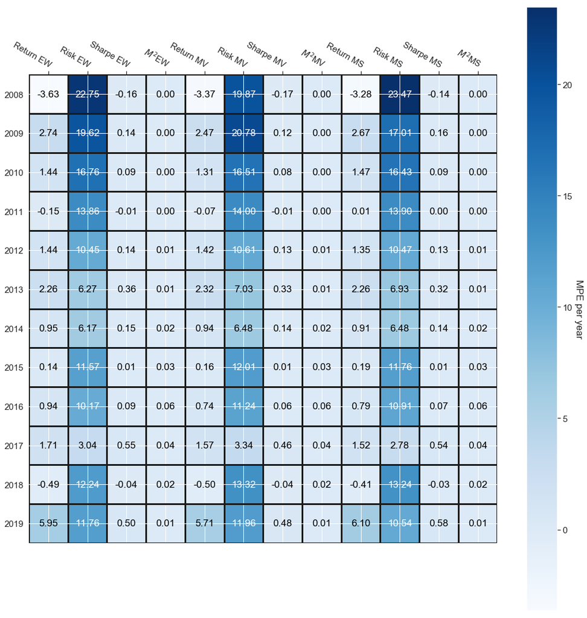

```python
fig, ax = plt.subplots(figsize=(15,15))

im, cbar = heatmap(datas, years, MAD, ax=ax,
                   cmap="Blues", cbarlabel="MPE per year")
texts = annotate_heatmap(im)
fig.tight_layout()
plt.savefig('MPE_.png')
plt.show()
```

```python
import plotly
plotly.tools.set_credentials_file(username='jazerape', api_key='1xEMmZcBSEn2Yj4NhYxD')
```

```python
import plotly.plotly as py
import plotly.graph_objs as go



trace1 = go.Scatter(
    x=years_m,
    y=rend_port,
    name='Rendimiento'
)
trace2 = go.Scatter(
    x=years_m,
    y=risk_ew,
    name='Volatilidad',
    yaxis='y2'
)
trace3 = go.Scatter(
    x=years_m,
    y=sharpe_ew,
    name='Ratio Sharpe',
    yaxis='y3'
)
trace4 = go.Scatter(
    x=years_m,
    y=mc_ew,
    name='$m^2$ ',
    yaxis='y4'
)
data = [trace1, trace2, trace3, trace4]
layout = go.Layout(
    title='Desempeño de Portafolio con ponderaciones iguales',
    width=1500,
    xaxis=dict(
        domain=[0.2, 0.7]
    ),
    yaxis=dict(
        title='y rend',
        titlefont=dict(
            color='#1f77b4'
        ),
        tickfont=dict(
            color='#1f77b4'
        )
    ),
    yaxis2=dict(
        title='y vol',
        titlefont=dict(
            color='#ff7f0e'
        ),
        tickfont=dict(
            color='#ff7f0e'
        ),
        anchor='free',
        overlaying='y',
        side='left',
        position=0.15
    ),
    yaxis3=dict(
        title='y $m^2$',
        titlefont=dict(
            color='#d62728'
        ),
        tickfont=dict(
            color='#d62728'
        ),
        anchor='x',
        overlaying='y',
        side='right'
    ),
    yaxis4=dict(
        title='y sharpe',
        titlefont=dict(
            color='green'
        ),
        tickfont=dict(
            color='green'
        ),
        anchor='free',
        overlaying='y',
        side='right',
        position=0.80
    )
)
fig = go.Figure(data=data, layout=layout)
py.iplot(fig, filename='multiple-axes-multiple')
```

[interactive chart not shown]

```python
ew_we= []
for i in range(len(equal_we)):
    nn = equal_we[i]/sum(equal_we)*100
    ew_we.append(nn)
```

```python
labels = selected
values = ew_we

trace = go.Pie(labels=labels, values=values, hole=.5)

py.iplot([trace], filename='basic_pie_chart', title='jolkmmc')
```

[interactive chart not shown]

```python
trace1 = go.Scatter(
    x=years_m,
    y=rend_port2,
    name='Rendimiento'
)
trace2 = go.Scatter(
    x=years_m,
    y=risk_pv,
    name='Volatilidad',
    yaxis='y2'
)
trace3 = go.Scatter(
    x=years_m,
    y=sharpe_pv,
    name='Ratio Sharpe',
    yaxis='y3'
)
trace4 = go.Scatter(
    x=years_m,
    y=mc_pv,
    name='$m^2$ ',
    yaxis='y4'
)
data = [trace1, trace2, trace3, trace4]
layout = go.Layout(
    title='Desempeño de Portafolio con ponderaciones min varianza',
    width=1500,
    xaxis=dict(
        domain=[0.2, 0.7]
    ),
    yaxis=dict(
        title='y rend',
        titlefont=dict(
            color='#1f77b4'
        ),
        tickfont=dict(
            color='#1f77b4'
        )
    ),
    yaxis2=dict(
        title='y vol',
        titlefont=dict(
            color='#ff7f0e'
        ),
        tickfont=dict(
            color='#ff7f0e'
        ),
        anchor='free',
        overlaying='y',
        side='left',
        position=0.15
    ),
    yaxis3=dict(
        title='y $m^2$',
        titlefont=dict(
            color='#d62728'
        ),
        tickfont=dict(
            color='#d62728'
        ),
        anchor='x',
        overlaying='y',
        side='right'
    ),
    yaxis4=dict(
        title='y sharpe',
        titlefont=dict(
            color='green'
        ),
        tickfont=dict(
            color='green'
        ),
        anchor='free',
        overlaying='y',
        side='right',
        position=0.80
    )
)
fig = go.Figure(data=data, layout=layout)
py.iplot(fig, filename='multiple-axes-multiple')
```

[interactive chart not shown]

```python
ew_pv= []
for i in range(len(pv)):
    nn = pv[i]/sum(pv)*100
    ew_pv.append(nn)
```

```python
labels = selected
values = ew_pv

trace = go.Pie(labels=labels, values=values, hole=.5)

py.iplot([trace], filename='basic_pie_chart', title='jolkmmc')
```

[interactive chart not shown]

```python
trace1 = go.Scatter(
    x=years_m,
    y=rend_port3,
    name='Rendimiento'
)
trace2 = go.Scatter(
    x=years_m,
    y=risk_ps,
    name='Volatilidad',
    yaxis='y2'
)
trace3 = go.Scatter(
    x=years_m,
    y=sharpe_ps,
    name='Ratio Sharpe',
    yaxis='y3'
)
trace4 = go.Scatter(
    x=years_m,
    y=mc_ps,
    name='$m^2$ ',
    yaxis='y4'
)
data = [trace1, trace2, trace3, trace4]
layout = go.Layout(
    title='Desempeño de Portafolio con ponderaciones max sharpe',
    width=1500,
    xaxis=dict(
        domain=[0.2, 0.7]
    ),
    yaxis=dict(
        title='y rend',
        titlefont=dict(
            color='#1f77b4'
        ),
        tickfont=dict(
            color='#1f77b4'
        )
    ),
    yaxis2=dict(
        title='y vol',
        titlefont=dict(
            color='#ff7f0e'
        ),
        tickfont=dict(
            color='#ff7f0e'
        ),
        anchor='free',
        overlaying='y',
        side='left',
        position=0.15
    ),
    yaxis3=dict(
        title='y $m^2$',
        titlefont=dict(
            color='#d62728'
        ),
        tickfont=dict(
            color='#d62728'
        ),
        anchor='x',
        overlaying='y',
        side='right'
    ),
    yaxis4=dict(
        title='y sharpe',
        titlefont=dict(
            color='green'
        ),
        tickfont=dict(
            color='green'
        ),
        anchor='free',
        overlaying='y',
        side='right',
        position=0.80
    )
)
fig = go.Figure(data=data, layout=layout)
py.iplot(fig, filename='multiple-axes-multiple')
```

[interactive chart not shown]

```python
ew_ps= []
for i in range(len(ps)):
    nn = ps[i]/sum(ps)*100

    ew_ps.append(nn)
```

```python
labels = selected
values = ew_ps

trace = go.Pie(labels=labels, values=values, hole=.5)

py.iplot([trace], filename='basic_pie_chart')
```

[interactive chart not shown]

# Criterion #2:

## Internal Rate of Return (IRR)

> The internal rate of return (IRR) is a metric used in capital budgeting to estimate the profitability of potential investments. The internal rate of return is a discount rate that makes the net present value (NPV) of all cash flows from a particular project equal to zero.

[figure not shown]

> The higher a project's internal rate of return, the more desirable it is to undertake. IRR is uniform for investments of varying types and, as such, IRR can be used to rank multiple prospective projects on a relatively even basis. Assuming the costs of investment are equal among the various projects, the project with the highest IRR would probably be considered the best and be undertaken first.

> IRR is useful for corporations in evaluating stock buyback programs. Clearly, if a company allocates a substantial amount to a stock buyback, the analysis must show that the company's own stock is a better investment (has a higher IRR) than any other use of the funds for other capital projects.

### Fist Analysis:

### Equal Weights in the Portfolio

#### STEP #1:

> Get the last NAV per year of each ETF in the sample that has been trading since 2008.

```python
# Function to get the last nav per year of each ETF

def ETF_nav(j):
    date=[]

    ETF_n = pd.read_csv(listas[j]) #Read files
    ETF_n = ETF_n.drop(columns = ['Index Level', 'Ex-Dividends', 'Shares Outstanding']) #Delete unnecessary columns
    for i in range(len(ETF_n["As Of"])):
            date.append(ETF_n["As Of"].iloc[i].replace("-"," ")) #Date Format
    table_n=pd.DataFrame(columns=['Cash Flow' ])
    table_n['As Of'] = date
    table_n['Cash Flow'] = ETF_n['NAV per Share']
    table_n['As Of'] = pd.to_datetime(table_n['As Of'], format='%d %b %y')
    nav_t = table_n.groupby(table_n['As Of'].dt.year)['Cash Flow'].agg('first') #Group by the last NAV per year
    return(nav_t)
```

```python
# Call the function ETF_nav that get the last NAV per year of each ETF

n0 = ETF_nav(0)
n1 = ETF_nav(1)
n2 = ETF_nav(2)
n3 = ETF_nav(3)
n4 = ETF_nav(4)
n5 = ETF_nav(5)
n6 = ETF_nav(6)
n7 = ETF_nav(7)
n8 = ETF_nav(8)
n9 = ETF_nav(9)
n10 = ETF_nav(10)
n11 = ETF_nav(11)
n12 = ETF_nav(12)
n13 = ETF_nav(13)
n14 = ETF_nav(14)
n15 = ETF_nav(15)
n16 = ETF_nav(16)
n17 = ETF_nav(17)
n18 = ETF_nav(18)
n19 = ETF_nav(19)
n20 = ETF_nav(20)
n21 = ETF_nav(21)
n22 = ETF_nav(22)
n23 = ETF_nav(23)
n24 = ETF_nav(24)
n25 = ETF_nav(25)
n26 = ETF_nav(26)
n27 = ETF_nav(27)
n28 = ETF_nav(28)
n29 = ETF_nav(29)
n30 = ETF_nav(30)
n31 = ETF_nav(31)


# Construction of a DATAFRAME with the last NAV per year of each ETF

na = pd.DataFrame({'Core SP 500': n0,'Core SP Mid Cap': n1,
                  'Core SP Total US Stock Market': n2,'Expanded Tech Sector': n3,
                  'Expanded Tech Software Sector': n4,'MSCI ACWI': n5,
                  'MSCI EAFE': n6,'MSCI Emerging Markets': n7, 'MSCI Japan': n8,
                  'MSCI USA ESG Select': n9, 'Nasdaq Biotechnology': n10,
                  'NorthAmerican Tech Multimedia Networking': n11,
                  'PHLX Semiconductor': n12, 'Preferred and Income Securities': n13,
                  'Russell 1000': n14, 'Russell 1000 Growth': n15,
                  'Russell 1000 Value': n16, 'Russell 2000': n17,
                  'SP 500 Growth': n18,'US Basic Materials': n19,
                  'US Consumer Services': n20, 'SP 500 Value': n21, 'US Energy': n22,
                  'US Financial Services': n23, 'US Financials': n24, 'US Healthcare': n25,
                  'Home Construction': n26, 'US Industrials': n27, 'US Medical Devices': n28,
                  'US Pharmaceuticals': n29, 'US Technology': n30,'US Telecommunications': n31})



pd.set_option('display.max_columns', 32) #Show all the columns in the DataFrame
na = na[12:23] #Selection from the year 2008 onwards
```

#### STEP #2:

> Get the Equal Weight in the Portfolio

```python
#Equal Weights in the Portfolio

inv = 100000 #Investment: 100k USD
pt = 1 #Total Weight of a portfolio: 100%
n_ind = len(na.loc[2008]) #Number of industries
ew = pt/n_ind #Equal Weighted
ipw_ew = ew*inv #Investment per weight
navs08 = na.loc[2008] #Net Asset Value (NAV) in 2008
```

```python
# Shares per ETF in 2008 with Equal Weights

tew_etf = ipw_ew/navs08
tew_etf = round(tew_etf)
```

#### STEP #3:

> Get the Net Asset Value (NAV) per year of each ETF

```python
#NAV per ETF with the same number of shares than in 2008

nav_ew = tew_etf*na
```

```python
a0 = nav_ew["Core SP 500"]
a1 = nav_ew["Core SP Mid Cap"]
a2 = nav_ew["Core SP Total US Stock Market"]
a3 = nav_ew["Expanded Tech Sector"]
a4 = nav_ew["Expanded Tech Software Sector"]
a5 = nav_ew["MSCI ACWI"]
a6 = nav_ew["MSCI EAFE"]
a7 = nav_ew["MSCI Emerging Markets"]
a8 = nav_ew["MSCI Japan"]
a9 = nav_ew["MSCI USA ESG Select"]
a10 = nav_ew["Nasdaq Biotechnology"]
a11 = nav_ew["NorthAmerican Tech Multimedia Networking"]
a12 = nav_ew["PHLX Semiconductor"]
a13 = nav_ew["Preferred and Income Securities"]
a14 = nav_ew["Russell 1000"]
a15 = nav_ew["Russell 1000 Growth"]
a16 = nav_ew["Russell 1000 Value"]
a17 = nav_ew["Russell 2000"]
a18 = nav_ew["SP 500 Growth"]
a19 = nav_ew["US Basic Materials"]
a20 = nav_ew["US Consumer Services"]
a21 = nav_ew["SP 500 Value"]
a22 = nav_ew["US Energy"]
a23 = nav_ew["US Financial Services"]
a24 = nav_ew["US Financials"]
a25 = nav_ew["US Healthcare"]
a26 = nav_ew["Home Construction"]
a27 = nav_ew["US Industrials"]
a28 = nav_ew["US Medical Devices"]
a29 = nav_ew["US Pharmaceuticals"]
a30 = nav_ew["US Technology"]
a31 = nav_ew["US Telecommunications"]
```

#### STEP #4:

> Once we have the NAV per ETF, we need to group the NAV by industries.

```python
#Group ETF's by Industries

Chemical_Materials = a19+a16
Consumer_Retail = a20+a5+a21
Electronics =  a1+a14+a17
Energy = a22+a7+a18
Environmental = a0+a6
Financial_Services = a13+a23+a24
Hardware_Systems =  a2+a8
HealthCare_Biotech =  a10+a25+a28+a29
Industrial =  a26+a27
Information_Technology = a3+a30
Manufacturing = a12+a15
Media_Communications = a11+a31
Software_Services = a4+a9
```

```python
#NAV's DataFrame by industries

ni_ew = pd.DataFrame({'Chemical/Materials': Chemical_Materials,
                   'Consumer/Retail': Consumer_Retail,
                   'Electronics': Electronics,
                   'Energy': Energy,
                   'Environmental': Environmental,
                   'Financial Services' : Financial_Services,
                   'Hardware/Systems': Hardware_Systems,
                   'HealthCare/Biotech': HealthCare_Biotech,
                   'Industrial': Industrial,
                   'Information Technology': Information_Technology,
                   'Manufacturing': Manufacturing,
                   'Media/Communications': Media_Communications,
                   'Software/Services': Software_Services})
```

#### STEP #5:

> Get the Net Present Value (NPV) per year of each industry

```python
#List of industries

lis_ind = ['Chemical/Materials', 'Consumer/Retail','Electronics', 'Energy','Environmental',
            'Financial Services' , 'Hardware/Systems', 'HealthCare/Biotech', 'Industrial',
            'Information Technology', 'Manufacturing','Media/Communications','Software/Services']
```

```python
#List of years that we'll use to get the Net Present Value (NPV)

t_tir= []
for i in range(0,12):
    t_tir.append(1+i)
t_tir.reverse()
```

```python
#List of discount rate 2008-2019

r = [0.005, 0.0073, 0.0075, 0.0075, 0.0075, 0.0075, 0.0077, 0.0102, 0.0138, .0225, 0.03]
```

```python
#Bottom part of the Net Present Values's (NPV) formula

d_npv =[]
for i in range(len(r)):
    bottom = (1+r[i])**(t_tir[i]) #(1+r)^t
    d_npv.append(bottom)
```

```python
#Formula of the Net Present Values (NPV)

t_npv_ew =[]
for i in range(len(lis_ind)):
    f_npv_ew = ni_ew[lis_ind[i]]/(d_npv) #Ct/(1+r^t)
    t_npv_ew.append(f_npv_ew)
```

```python
#Initial investment per industry

in_in_ew = [-2*ipw_ew, -3*ipw_ew, -3*ipw_ew, -3*ipw_ew, -2*ipw_ew, -3*ipw_ew, -2*ipw_ew, -4*ipw_ew, -2*ipw_ew, -2*ipw_ew, -2*ipw_ew, -2*ipw_ew, -2*ipw_ew]
```

```python
#NPV's DataFrame by industries

npv_ew = pd.DataFrame(t_npv_ew).T
npv_ew.loc[2007] = in_in_ew
npv_ew = npv_ew.sort_index()
```

#### STEP #6:

> Get the Internal Rate of Return (IRR) per year of each industry

```python
#npv_ew's column list per industry

lis_i = [npv_ew['Chemical/Materials'], npv_ew['Consumer/Retail'], npv_ew['Electronics'], npv_ew['Energy'], npv_ew['Environmental'],
         npv_ew['Financial Services'] , npv_ew['Hardware/Systems'], npv_ew['HealthCare/Biotech'], npv_ew['Industrial'],
         npv_ew['Information Technology'], npv_ew['Manufacturing'], npv_ew['Media/Communications'], npv_ew['Software/Services']]
```

```python
#Convertion of each column to an array

lis_irr = [np.array(i) for i in lis_i]
```

```python
#IRR's formula using "np.irr"

t_t = []
for i in range(len(lis_irr)):
    t_a = []
    for j in range(2,13):
        tir = np.irr(lis_irr[i][:j])
        t_a.append(tir)
    t_t.append(t_a)
```

```python
#List of year we'll use in the IRR's DataFrame

y_tir = []
for i in range(2008,2019):
    y_tir.append(1+i)
```

```python
#IRR's DataFrame by industries

irr_df = pd.DataFrame(columns = lis_ind)
irr_df['Chemical/Materials'] = (t_t)[0]
irr_df['Consumer/Retail'] = (t_t)[1]
irr_df['Electronics'] = (t_t)[2]
irr_df['Energy'] = (t_t)[3]
irr_df['Environmental'] = (t_t)[4]
irr_df['Financial Services'] = (t_t)[5]
irr_df['Hardware/Systems'] = (t_t)[6]
irr_df['HealthCare/Biotech'] = (t_t)[7]
irr_df['Industrial'] = (t_t)[8]
irr_df['Information Technology'] = (t_t)[9]
irr_df['Manufacturing'] = (t_t)[10]
irr_df['Media/Communications'] = (t_t)[11]
irr_df['Software/Services'] = (t_t)[12]
irr_df['Year'] = y_tir
irr_df = irr_df.set_index('Year')
```

```python
years = y_tir
MAD = lis_ind

datas = np.array([ irr_df.loc[2009],irr_df.loc[2010],irr_df.loc[2011],irr_df.loc[2012],irr_df.loc[2013],
                   irr_df.loc[2014],irr_df.loc[2015],irr_df.loc[2016],irr_df.loc[2017],irr_df.loc[2018],
                   irr_df.loc[2019] ])
```

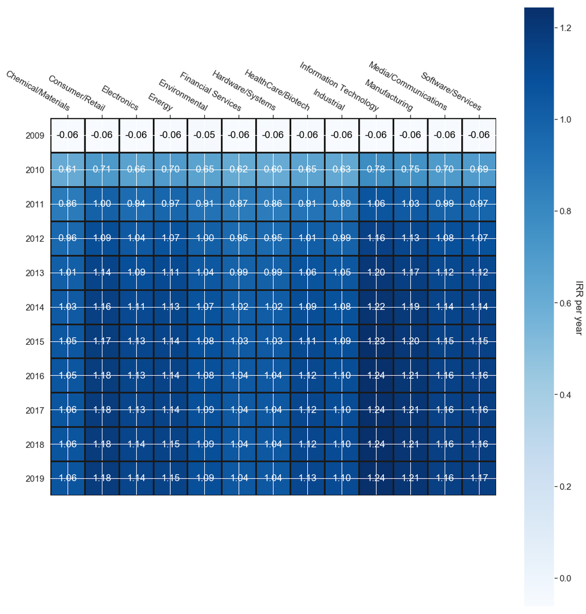

```python
fig, ax = plt.subplots(figsize=(15,15))

im, cbar = heatmap(datas, years, MAD, ax=ax,
                   cmap="Blues", cbarlabel="IRR per year")
#Colors: PuBu, RdBu, Blues, coolwarm
texts = annotate_heatmap(im)


fig.tight_layout()
plt.savefig('irr_ew.png')
plt.show()
```

## Equal Weights in the Portfolio

```python
ew_wei= []
for i in range(len(in_in_ew)):
    nn = in_in_ew[i]/sum(in_in_ew)*100
    ew_wei.append(nn)
```

```python
labels = lis_ind
values = ew_wei

trace = go.Pie(labels=labels, values=values, hole=.5, title = "Equal Weights")

py.iplot([trace], filename='basic_pie_chart')
```

[interactive chart not shown]

## Time Series

```python
irr_1 = go.Scatter(x=y_tir, y=irr_df['Chemical/Materials'], name = 'Chemical Material', line = dict(color = "skyblue"),
                   opacity = 0.8)
irr_2 = go.Scatter(x=y_tir, y=irr_df['Consumer/Retail'], name = 'Consumer Retail', line = dict(color = "deepskyblue"),
                   opacity = 0.8)
irr_3 = go.Scatter(x=y_tir, y=irr_df['Electronics'], name = 'Electronics', line = dict(color = "aliceblue"),
                   opacity = 0.8)
irr_4 = go.Scatter(x=y_tir, y=irr_df['Energy'], name = 'Energy', line = dict(color = "cadetblue"),
                   opacity = 0.8)
irr_5 = go.Scatter(x=y_tir, y=irr_df['Environmental'], name = 'Environmental', line = dict(color = "steelblue"),
                   opacity = 0.8)
irr_6 = go.Scatter(x=y_tir, y=irr_df['Financial Services'], name = 'Financial Services', line = dict(color = "lightskyblue"),
                   opacity = 0.8)
irr_7 = go.Scatter(x=y_tir, y=irr_df['Hardware/Systems'], name = 'Hardware Systems', line = dict(color = "darkturquoise"),
                   opacity = 0.8)
irr_8 = go.Scatter(x=y_tir, y=irr_df['HealthCare/Biotech'], name = 'HealthCare Biotech', line = dict(color = "darkblue"),
                   opacity = 0.8)
irr_9 = go.Scatter(x=y_tir, y=irr_df['Industrial'], name = 'Idustrial', line = dict(color = "powderblue"),
                   opacity = 0.8)
irr_10 = go.Scatter(x=y_tir, y=irr_df['Information Technology'], name = 'Information Technology', line = dict(color = "darkcyan"),
                   opacity = 0.8)
irr_11 = go.Scatter(x=y_tir, y=irr_df['Manufacturing'], name = 'Manufacturing', line = dict(color = "midnightblue"),
                   opacity = 0.8)
irr_12 = go.Scatter(x=y_tir, y=irr_df['Media/Communications'], name = 'Media Communications', line = dict(color = "navy"),
                   opacity = 0.8)
irr_13 = go.Scatter(x=y_tir, y=irr_df['Software/Services'], name = 'Software Services', line = dict(color = "lightblue"),
                   opacity = 0.8)


data = [irr_1,irr_2,irr_3,irr_4,irr_5,irr_6,irr_7,irr_8,irr_9,irr_10,irr_11,irr_12,irr_13]

layout = dict(title = "IRR Equal Weights 2009-2019")


fig = dict(data=data, layout=layout)
py.iplot(fig, filename = "IRR Equal Weights 2009-2019")
```

[interactive chart not shown]

### Second Analysis:

### Weights in the Portfolio using Markowitz's Minimun Variance

#### STEP #1:

> Get the last NAV per year of each ETF in the sample that has been trading since 2008.

#### STEP #2:

> Get the Weights in the Portfolio using Markowitz's Minimun Variance

```python
#Weights in the Portfolio using Markowitz's Minimun Variance

#inv = 100000 #Investment: 100k USD

#Weights in the Portfolio per ETF
mv = min_variance_port.drop(columns = ['Returns', 'Volatility', 'Sharpe Ratio'])
mv['Year'] = 2008
mv = mv.set_index('Year')

ipw_mv = mv.loc[2008]*inv #Investment per weight
navs08 = na.loc[2008] #Net Asset Value (NAV) in 2008
```

```python
# Shares per ETF in 2008

tmv_etf = ipw_mv/navs08
tmv_etf = round(tmv_etf)
```

#### STEP #3:

> Get the Net Asset Value (NAV) per year of each ETF

```python
#NAV per ETF with the same number of shares than in 2008

nav_mv = tmv_etf*na
```

```python
mva0 = nav_mv["Core SP 500"]
mva1 = nav_mv["Core SP Mid Cap"]
mva2 = nav_mv["Core SP Total US Stock Market"]
mva3 = nav_mv["Expanded Tech Sector"]
mva4 = nav_mv["Expanded Tech Software Sector"]
mva5 = nav_mv["MSCI ACWI"]
mva6 = nav_mv["MSCI EAFE"]
mva7 = nav_mv["MSCI Emerging Markets"]
mva8 = nav_mv["MSCI Japan"]
mva9 = nav_mv["MSCI USA ESG Select"]
mva10 = nav_mv["Nasdaq Biotechnology"]
mva11 = nav_mv["NorthAmerican Tech Multimedia Networking"]
mva12 = nav_mv["PHLX Semiconductor"]
mva13 = nav_mv["Preferred and Income Securities"]
mva14 = nav_mv["Russell 1000"]
mva15 = nav_mv["Russell 1000 Growth"]
mva16 = nav_mv["Russell 1000 Value"]
mva17 = nav_mv["Russell 2000"]
mva18 = nav_mv["SP 500 Growth"]
mva19 = nav_mv["US Basic Materials"]
mva20 = nav_mv["US Consumer Services"]
mva21 = nav_mv["SP 500 Value"]
mva22 = nav_mv["US Energy"]
mva23 = nav_mv["US Financial Services"]
mva24 = nav_mv["US Financials"]
mva25 = nav_mv["US Healthcare"]
mva26 = nav_mv["Home Construction"]
mva27 = nav_mv["US Industrials"]
mva28 = nav_mv["US Medical Devices"]
mva29 = nav_mv["US Pharmaceuticals"]
mva30 = nav_mv["US Technology"]
mva31 = nav_mv["US Telecommunications"]
```

#### STEP #4:

> Once we have the NAV per ETF, we need to group the NAV by industries.

```python
#Group ETF's by Industries

Chemical_Materials = mva19+mva16
Consumer_Retail = mva20+mva5+mva21
Electronics =  mva1+mva14+mva17
Energy = mva22+mva7+mva18
Environmental = mva0+mva6
Financial_Services = mva13+mva23+mva24
Hardware_Systems = mva2+mva8
HealthCare_Biotech = mva10+mva25+mva28+mva29
Industrial = mva26+mva27
Information_Technology = mva3+mva30
Manufacturing = mva12+mva15
Media_Communications = mva11+mva31
Software_Services = mva4+mva9
```

```python
#NAV's DataFrame by industries

ni_mv = pd.DataFrame({'Chemical/Materials': Chemical_Materials,
                   'Consumer/Retail': Consumer_Retail,
                   'Electronics': Electronics,
                   'Energy': Energy,
                   'Environmental': Environmental,
                   'Financial Services' : Financial_Services,
                   'Hardware/Systems': Hardware_Systems,
                   'HealthCare/Biotech': HealthCare_Biotech,
                   'Industrial': Industrial,
                   'Information Technology': Information_Technology,
                   'Manufacturing': Manufacturing,
                   'Media/Communications': Media_Communications,
                   'Software/Services': Software_Services})
```

#### STEP #5:

> Get the Net Present Value (NPV) per year of each industry

```python
#Formula of the Net Present Values (NPV)

t_npv_mv =[]
for i in range(len(lis_ind)):
    f_npv = ni_mv[lis_ind[i]]/(d_npv) #Ct/(1+r^t)
    t_npv_mv.append(f_npv)
```

```python
#Initial investment per industry

wmva0 = -ipw_mv["Core SP 500"]
wmva1 = -ipw_mv["Core SP Mid Cap"]
wmva2 = -ipw_mv["Core SP Total US Stock Market"]
wmva3 = -ipw_mv["Expanded Tech Sector"]
wmva4 = -ipw_mv["Expanded Tech Software Sector"]
wmva5 = -ipw_mv["MSCI ACWI"]
wmva6 = -ipw_mv["MSCI EAFE"]
wmva7 = -ipw_mv["MSCI Emerging Markets"]
wmva8 = -ipw_mv["MSCI Japan"]
wmva9 = -ipw_mv["MSCI USA ESG Select"]
wmva10 = -ipw_mv["Nasdaq Biotechnology"]
wmva11 = -ipw_mv["NorthAmerican Tech Multimedia Networking"]
wmva12 = -ipw_mv["PHLX Semiconductor"]
wmva13 = -ipw_mv["Preferred and Income Securities"]
wmva14 = -ipw_mv["Russell 1000"]
wmva15 = -ipw_mv["Russell 1000 Growth"]
wmva16 = -ipw_mv["Russell 1000 Value"]
wmva17 = -ipw_mv["Russell 2000"]
wmva18 = -ipw_mv["SP 500 Growth"]
wmva19 = -ipw_mv["US Basic Materials"]
wmva20 = -ipw_mv["US Consumer Services"]
wmva21 = -ipw_mv["SP 500 Value"]
wmva22 = -ipw_mv["US Energy"]
wmva23 = -ipw_mv["US Financial Services"]
wmva24 = -ipw_mv["US Financials"]
wmva25 = -ipw_mv["US Healthcare"]
wmva26 = -ipw_mv["Home Construction"]
wmva27 = -ipw_mv["US Industrials"]
wmva28 = -ipw_mv["US Medical Devices"]
wmva29 = -ipw_mv["US Pharmaceuticals"]
wmva30 = -ipw_mv["US Technology"]
wmva31 = -ipw_mv["US Telecommunications"]
```

```python
#Group ETF's by Industries

Chemical_Materials = wmva19+wmva16
Consumer_Retail = wmva20+wmva5+wmva21
Electronics =  wmva1+wmva14+wmva17
Energy = wmva22+wmva7+wmva18
Environmental = wmva0+wmva6
Financial_Services = wmva13+wmva23+wmva24
Hardware_Systems = wmva2+wmva8
HealthCare_Biotech = wmva10+wmva25+wmva28+wmva29
Industrial = wmva26+wmva27
Information_Technology = wmva3+wmva30
Manufacturing = wmva12+wmva15
Media_Communications = wmva11+wmva31
Software_Services = wmva4+wmva9
```

```python
#Initial investment per industry

in_in_mv = [Chemical_Materials, Consumer_Retail, Electronics, Energy, Environmental,
            Financial_Services , Hardware_Systems, HealthCare_Biotech, Industrial,
            Information_Technology, Manufacturing, Media_Communications, Software_Services]
```

```python
#NPV's DataFrame by industries

npv_mv = pd.DataFrame(t_npv_mv).T
npv_mv.loc[2007] = in_in_mv
npv_mv = npv_mv.sort_index()
```

#### STEP #6:

> Get the Internal Rate of Return (IRR) per year of each industry

```python
#npv_mv's column list per industry

lis_i = [npv_mv['Chemical/Materials'], npv_mv['Consumer/Retail'], npv_mv['Electronics'], npv_mv['Energy'], npv_mv['Environmental'],
         npv_mv['Financial Services'] , npv_mv['Hardware/Systems'], npv_mv['HealthCare/Biotech'], npv_mv['Industrial'],
         npv_mv['Information Technology'], npv_mv['Manufacturing'], npv_mv['Media/Communications'], npv_mv['Software/Services']]
```

```python
#Convertion of each column to an array

lis_irr = [np.array(i) for i in lis_i]
```

```python
#IRR's formula using "np.irr"

t_t_mv = []
for i in range(len(lis_irr)):
    t_a = []
    for j in range(2,13):
        tir = np.irr(lis_irr[i][:j])
        t_a.append(tir)
    t_t_mv.append(t_a)
```

```python
#IRR's DataFrame by industries

irr_df = pd.DataFrame(columns = lis_ind)
irr_df['Chemical/Materials'] = (t_t_mv)[0]
irr_df['Consumer/Retail'] = (t_t_mv)[1]
irr_df['Electronics'] = (t_t_mv)[2]
irr_df['Energy'] = (t_t_mv)[3]
irr_df['Environmental'] = (t_t_mv)[4]
irr_df['Financial Services'] = (t_t_mv)[5]
irr_df['Hardware/Systems'] = (t_t_mv)[6]
irr_df['HealthCare/Biotech'] = (t_t_mv)[7]
irr_df['Industrial'] = (t_t_mv)[8]
irr_df['Information Technology'] = (t_t_mv)[9]
irr_df['Manufacturing'] = (t_t_mv)[10]
irr_df['Media/Communications'] = (t_t_mv)[11]
irr_df['Software/Services'] = (t_t_mv)[12]
irr_df['Year'] = y_tir
irr_df = irr_df.set_index('Year')
```

```python
years = y_tir
MAD = lis_ind

datas = np.array([ irr_df.loc[2009],irr_df.loc[2010],irr_df.loc[2011],irr_df.loc[2012],irr_df.loc[2013],
                   irr_df.loc[2014],irr_df.loc[2015],irr_df.loc[2016],irr_df.loc[2017],irr_df.loc[2018],
                   irr_df.loc[2019] ])
```

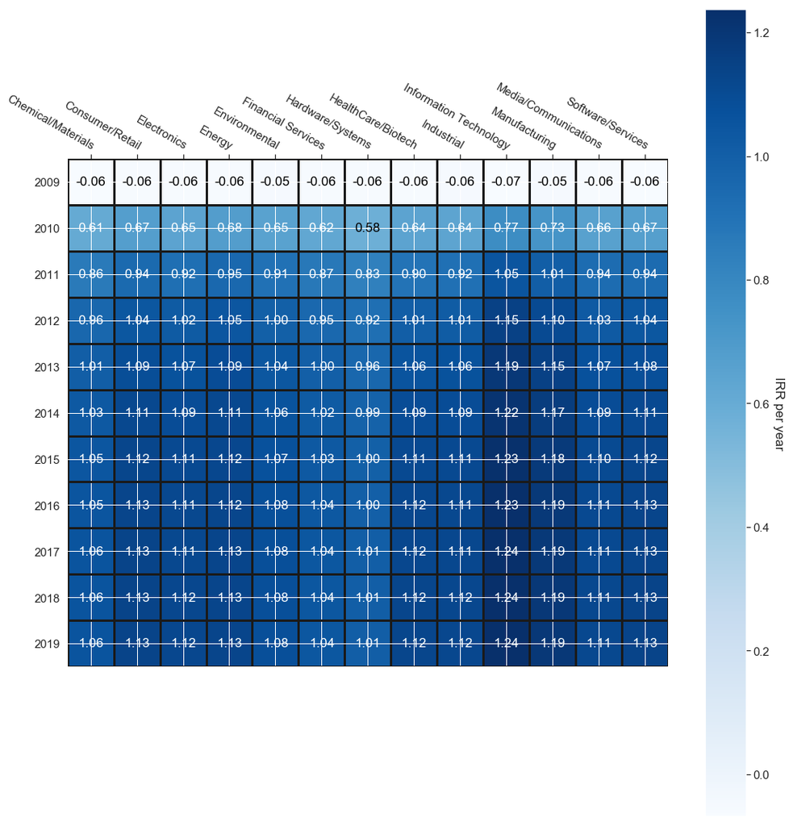

```python
fig, ax = plt.subplots(figsize=(15,15))

im, cbar = heatmap(datas, years, MAD, ax=ax,
                   cmap="Blues", cbarlabel="IRR per year")
#Colors: PuBu, RdBu, Blues
texts = annotate_heatmap(im)


fig.tight_layout()
plt.savefig('irr_mv.png')
plt.show()
```

## Markowitz's Minimun Variance Portfolio Weights

```python
mv_wei= []
for i in range(len(in_in_mv)):
    ll = in_in_mv[i]/sum(in_in_mv)*100
    mv_wei.append(ll)
```

```python
labels = lis_ind
values = mv_wei

trace = go.Pie(labels=labels, values=values, hole=.5, title = "Min Variance Weights")

py.iplot([trace], filename='basic_pie_chart')
```

[interactive chart not shown]

## Time Series

```python
irr_1 = go.Scatter(x=y_tir, y=irr_df['Chemical/Materials'], name = 'Chemical Material', line = dict(color = "skyblue"),
                   opacity = 0.8)
irr_2 = go.Scatter(x=y_tir, y=irr_df['Consumer/Retail'], name = 'Consumer Retail', line = dict(color = "deepskyblue"),
                   opacity = 0.8)
irr_3 = go.Scatter(x=y_tir, y=irr_df['Electronics'], name = 'Electronics', line = dict(color = "aliceblue"),
                   opacity = 0.8)
irr_4 = go.Scatter(x=y_tir, y=irr_df['Energy'], name = 'Energy', line = dict(color = "cadetblue"),
                   opacity = 0.8)
irr_5 = go.Scatter(x=y_tir, y=irr_df['Environmental'], name = 'Environmental', line = dict(color = "steelblue"),
                   opacity = 0.8)
irr_6 = go.Scatter(x=y_tir, y=irr_df['Financial Services'], name = 'Financial Services', line = dict(color = "lightskyblue"),
                   opacity = 0.8)
irr_7 = go.Scatter(x=y_tir, y=irr_df['Hardware/Systems'], name = 'Hardware Systems', line = dict(color = "darkturquoise"),
                   opacity = 0.8)
irr_8 = go.Scatter(x=y_tir, y=irr_df['HealthCare/Biotech'], name = 'HealthCare Biotech', line = dict(color = "darkblue"),
                   opacity = 0.8)
irr_9 = go.Scatter(x=y_tir, y=irr_df['Industrial'], name = 'Idustrial', line = dict(color = "powderblue"),
                   opacity = 0.8)
irr_10 = go.Scatter(x=y_tir, y=irr_df['Information Technology'], name = 'Information Technology', line = dict(color = "darkcyan"),
                   opacity = 0.8)
irr_11 = go.Scatter(x=y_tir, y=irr_df['Manufacturing'], name = 'Manufacturing', line = dict(color = "midnightblue"),
                   opacity = 0.8)
irr_12 = go.Scatter(x=y_tir, y=irr_df['Media/Communications'], name = 'Media Communications', line = dict(color = "navy"),
                   opacity = 0.8)
irr_13 = go.Scatter(x=y_tir, y=irr_df['Software/Services'], name = 'Software Services', line = dict(color = "lightblue"),
                   opacity = 0.8)


data = [irr_1,irr_2,irr_3,irr_4,irr_5,irr_6,irr_7,irr_8,irr_9,irr_10,irr_11,irr_12,irr_13]

layout = dict(title = "IRR Min Variance Weights 2009-2019")


fig = dict(data=data, layout=layout)
py.iplot(fig, filename = "IRR Min Variance Weights 2009-2019")
```

[interactive chart not shown]

### Third Analysis:

### Weights in the Portfolio using Markowitz's Maximum Sharpe

#### STEP #1:

> Get the last NAV per year of each ETF in the sample that has been trading since 2008.

#### STEP #2:

> Get the Weights in the Portfolio using Markowitz's Maximum Sharpe

```python
#Weights in the Portfolio using Markowitz's Maximum Sharpe

#inv = 100000 #Investment: 100k USD

#Weights in the Portfolio per ETF
ms = sharpe_portfolio.drop(columns = ['Returns', 'Volatility', 'Sharpe Ratio'])
ms['Year'] = 2008
ms = ms.set_index('Year')

ipw_ms = ms.loc[2008]*inv #Investment per weight
navs08 = na.loc[2008] #Net Asset Value (NAV) in 2008
```

```python
# Shares per ETF in 2008

tms_etf = ipw_ms/navs08
tms_etf = round(tms_etf)
```

#### STEP #3:

> Get the Net Asset Value (NAV) per year of each ETF

```python
#NAV per ETF with the same number of shares than in 2008

nav_ms = tms_etf*na
```

```python
msa0 = nav_ms["Core SP 500"]
msa1 = nav_ms["Core SP Mid Cap"]
msa2 = nav_ms["Core SP Total US Stock Market"]
msa3 = nav_ms["Expanded Tech Sector"]
msa4 = nav_ms["Expanded Tech Software Sector"]
msa5 = nav_ms["MSCI ACWI"]
msa6 = nav_ms["MSCI EAFE"]
msa7 = nav_ms["MSCI Emerging Markets"]
msa8 = nav_ms["MSCI Japan"]
msa9 = nav_ms["MSCI USA ESG Select"]
msa10 = nav_ms["Nasdaq Biotechnology"]
msa11 = nav_ms["NorthAmerican Tech Multimedia Networking"]
msa12 = nav_ms["PHLX Semiconductor"]
msa13 = nav_ms["Preferred and Income Securities"]
msa14 = nav_ms["Russell 1000"]
msa15 = nav_ms["Russell 1000 Growth"]
msa16 = nav_ms["Russell 1000 Value"]
msa17 = nav_ms["Russell 2000"]
msa18 = nav_ms["SP 500 Growth"]
msa19 = nav_ms["US Basic Materials"]
msa20 = nav_ms["US Consumer Services"]
msa21 = nav_ms["SP 500 Value"]
msa22 = nav_ms["US Energy"]
msa23 = nav_ms["US Financial Services"]
msa24 = nav_ms["US Financials"]
msa25 = nav_ms["US Healthcare"]
msa26 = nav_ms["Home Construction"]
msa27 = nav_ms["US Industrials"]
msa28 = nav_ms["US Medical Devices"]
msa29 = nav_ms["US Pharmaceuticals"]
msa30 = nav_ms["US Technology"]
msa31 = nav_ms["US Telecommunications"]
```

#### STEP #4:

> Once we have the NAV per ETF, we need to group the NAV by industries.

```python
#Group ETF's by Industries

Chemical_Materials = msa19+msa16
Consumer_Retail = msa20+msa5+msa21
Electronics =  msa1+msa14+msa17
Energy = msa22+msa7+msa18
Environmental = msa0+msa6
Financial_Services = msa13+msa23+msa24
Hardware_Systems = msa2+msa8
HealthCare_Biotech = msa10+msa25+msa28+msa29
Industrial = msa26+msa27
Information_Technology = msa3+msa30
Manufacturing = msa12+msa15
Media_Communications = msa11+msa31
Software_Services = msa4+msa9
```

```python
#NAV's DataFrame by industries

ni_ms = pd.DataFrame({'Chemical/Materials': Chemical_Materials,
                   'Consumer/Retail': Consumer_Retail,
                   'Electronics': Electronics,
                   'Energy': Energy,
                   'Environmental': Environmental,
                   'Financial Services' : Financial_Services,
                   'Hardware/Systems': Hardware_Systems,
                   'HealthCare/Biotech': HealthCare_Biotech,
                   'Industrial': Industrial,
                   'Information Technology': Information_Technology,
                   'Manufacturing': Manufacturing,
                   'Media/Communications': Media_Communications,
                   'Software/Services': Software_Services})
```

#### STEP #5:

> Get the Net Present Value (NPV) per year of each industry

```python
#Formula of the Net Present Values (NPV)

t_npv_ms =[]
for i in range(len(lis_ind)):
    f_npv = ni_ms[lis_ind[i]]/(d_npv) #Ct/(1+r^t)
    t_npv_ms.append(f_npv)
```

```python
#Initial investment per industry

wmsa0 = -ipw_ms["Core SP 500"]
wmsa1 = -ipw_ms["Core SP Mid Cap"]
wmsa2 = -ipw_ms["Core SP Total US Stock Market"]
wmsa3 = -ipw_ms["Expanded Tech Sector"]
wmsa4 = -ipw_ms["Expanded Tech Software Sector"]
wmsa5 = -ipw_ms["MSCI ACWI"]
wmsa6 = -ipw_ms["MSCI EAFE"]
wmsa7 = -ipw_ms["MSCI Emerging Markets"]
wmsa8 = -ipw_ms["MSCI Japan"]
wmsa9 = -ipw_ms["MSCI USA ESG Select"]
wmsa10 = -ipw_ms["Nasdaq Biotechnology"]
wmsa11 = -ipw_ms["NorthAmerican Tech Multimedia Networking"]
wmsa12 = -ipw_ms["PHLX Semiconductor"]
wmsa13 = -ipw_ms["Preferred and Income Securities"]
wmsa14 = -ipw_ms["Russell 1000"]
wmsa15 = -ipw_ms["Russell 1000 Growth"]
wmsa16 = -ipw_ms["Russell 1000 Value"]
wmsa17 = -ipw_ms["Russell 2000"]
wmsa18 = -ipw_ms["SP 500 Growth"]
wmsa19 = -ipw_ms["US Basic Materials"]
wmsa20 = -ipw_ms["US Consumer Services"]
wmsa21 = -ipw_ms["SP 500 Value"]
wmsa22 = -ipw_ms["US Energy"]
wmsa23 = -ipw_ms["US Financial Services"]
wmsa24 = -ipw_ms["US Financials"]
wmsa25 = -ipw_ms["US Healthcare"]
wmsa26 = -ipw_ms["Home Construction"]
wmsa27 = -ipw_ms["US Industrials"]
wmsa28 = -ipw_ms["US Medical Devices"]
wmsa29 = -ipw_ms["US Pharmaceuticals"]
wmsa30 = -ipw_ms["US Technology"]
wmsa31 = -ipw_ms["US Telecommunications"]
```

```python
#Group ETF's by Industries

Chemical_Materials = wmsa19+wmsa16
Consumer_Retail = wmsa20+wmsa5+wmsa21
Electronics =  wmsa1+wmsa14+wmsa17
Energy = wmsa22+wmsa7+wmsa18
Environmental = wmsa0+wmsa6
Financial_Services = wmsa13+wmsa23+wmsa24
Hardware_Systems = wmsa2+wmsa8
HealthCare_Biotech = wmsa10+wmsa25+wmsa28+wmsa29
Industrial = wmsa26+wmsa27
Information_Technology = wmsa3+wmsa30
Manufacturing = wmsa12+wmsa15
Media_Communications = wmsa11+wmsa31
Software_Services = wmsa4+wmsa9
```

```python
#Initial investment per industry

in_in_ms = [Chemical_Materials, Consumer_Retail, Electronics, Energy, Environmental,
            Financial_Services , Hardware_Systems, HealthCare_Biotech, Industrial,
            Information_Technology, Manufacturing, Media_Communications, Software_Services]
```

```python
#NPV's DataFrame by industries

npv_ms = pd.DataFrame(t_npv_ms).T
npv_ms.loc[2007] = in_in_ms
npv_ms = npv_ms.sort_index()
```

#### STEP #6:

> Get the Internal Rate of Return (IRR) per year of each industry

```python
#npv_ms's column list per industry

lis_i = [npv_ms['Chemical/Materials'], npv_ms['Consumer/Retail'], npv_ms['Electronics'], npv_ms['Energy'], npv_ms['Environmental'],
         npv_ms['Financial Services'] , npv_ms['Hardware/Systems'], npv_ms['HealthCare/Biotech'], npv_ms['Industrial'],
         npv_ms['Information Technology'], npv_ms['Manufacturing'], npv_ms['Media/Communications'], npv_ms['Software/Services']]
```

```python
#Convertion of each column to an array

lis_irr = [np.array(i) for i in lis_i]
```

```python
#IRR's formula using "np.irr"

t_t_ms = []
for i in range(len(lis_irr)):
    t_a = []
    for j in range(2,13):
        tir = np.irr(lis_irr[i][:j])
        t_a.append(tir)
    t_t_ms.append(t_a)
```

```python
#IRR's DataFrame by industries

irr_df = pd.DataFrame(columns = lis_ind)
irr_df['Chemical/Materials'] = (t_t_ms)[0]
irr_df['Consumer/Retail'] = (t_t_ms)[1]
irr_df['Electronics'] = (t_t_ms)[2]
irr_df['Energy'] = (t_t_ms)[3]
irr_df['Environmental'] = (t_t_ms)[4]
irr_df['Financial Services'] = (t_t_ms)[5]
irr_df['Hardware/Systems'] = (t_t_ms)[6]
irr_df['HealthCare/Biotech'] = (t_t_ms)[7]
irr_df['Industrial'] = (t_t_ms)[8]
irr_df['Information Technology'] = (t_t_ms)[9]
irr_df['Manufacturing'] = (t_t_ms)[10]
irr_df['Media/Communications'] = (t_t_ms)[11]
irr_df['Software/Services'] = (t_t_ms)[12]
irr_df['Year'] = y_tir
irr_df = irr_df.set_index('Year')
```

```python
years = y_tir
MAD = lis_ind

datas = np.array([ irr_df.loc[2009],irr_df.loc[2010],irr_df.loc[2011],irr_df.loc[2012],irr_df.loc[2013],
                   irr_df.loc[2014],irr_df.loc[2015],irr_df.loc[2016],irr_df.loc[2017],irr_df.loc[2018],
                   irr_df.loc[2019] ])
```

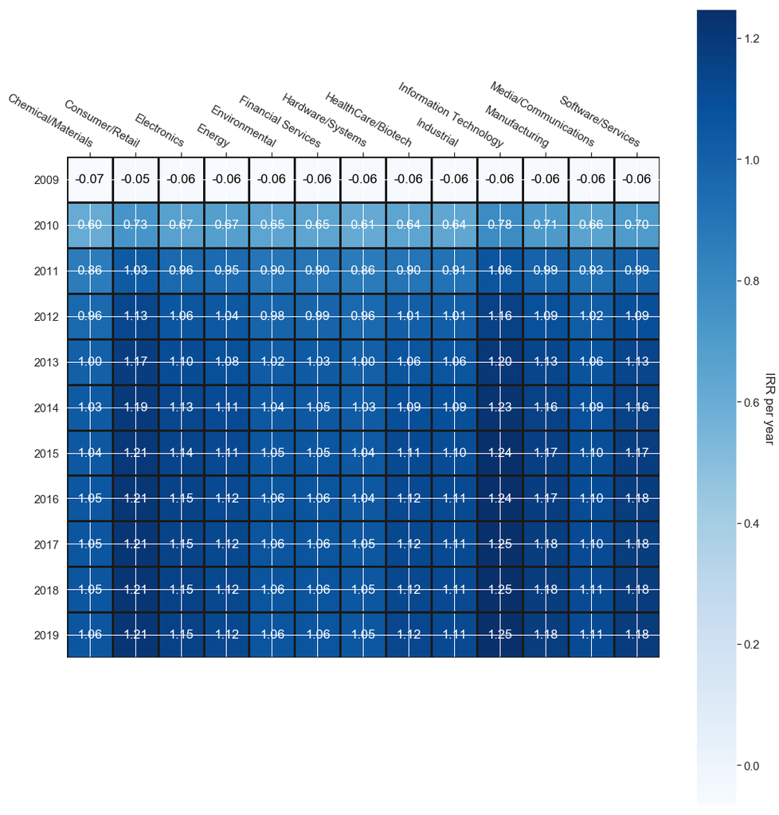

```python
fig, ax = plt.subplots(figsize=(15,15))

im, cbar = heatmap(datas, years, MAD, ax=ax,
                   cmap="Blues", cbarlabel="IRR per year")
#Colors: PuBu, RdBu, Blues
texts = annotate_heatmap(im)


fig.tight_layout()
plt.savefig('irr_ms.png')
plt.show()
```

## Markowitz's Maximum Sharpe Portfolio Weights

```python
ms_wei= []
for i in range(len(in_in_ms)):
    hh = in_in_ms[i]/sum(in_in_ms)*100
    ms_wei.append(hh)
```

```python
labels = lis_ind
values = ms_wei

trace = go.Pie(labels=labels, values=values, hole=.5, title = "Max Sharpe Weights")

py.iplot([trace], filename='basic_pie_chart')
```

[interactive chart not shown]

## Time Series

```python
irr_1 = go.Scatter(x=y_tir, y=irr_df['Chemical/Materials'], name = 'Chemical Material', line = dict(color = "skyblue"),
                   opacity = 0.8)
irr_2 = go.Scatter(x=y_tir, y=irr_df['Consumer/Retail'], name = 'Consumer Retail', line = dict(color = "deepskyblue"),
                   opacity = 0.8)
irr_3 = go.Scatter(x=y_tir, y=irr_df['Electronics'], name = 'Electronics', line = dict(color = "aliceblue"),
                   opacity = 0.8)
irr_4 = go.Scatter(x=y_tir, y=irr_df['Energy'], name = 'Energy', line = dict(color = "cadetblue"),
                   opacity = 0.8)
irr_5 = go.Scatter(x=y_tir, y=irr_df['Environmental'], name = 'Environmental', line = dict(color = "steelblue"),
                   opacity = 0.8)
irr_6 = go.Scatter(x=y_tir, y=irr_df['Financial Services'], name = 'Financial Services', line = dict(color = "lightskyblue"),
                   opacity = 0.8)
irr_7 = go.Scatter(x=y_tir, y=irr_df['Hardware/Systems'], name = 'Hardware Systems', line = dict(color = "darkturquoise"),
                   opacity = 0.8)
irr_8 = go.Scatter(x=y_tir, y=irr_df['HealthCare/Biotech'], name = 'HealthCare Biotech', line = dict(color = "darkblue"),
                   opacity = 0.8)
irr_9 = go.Scatter(x=y_tir, y=irr_df['Industrial'], name = 'Idustrial', line = dict(color = "powderblue"),
                   opacity = 0.8)
irr_10 = go.Scatter(x=y_tir, y=irr_df['Information Technology'], name = 'Information Technology', line = dict(color = "darkcyan"),
                   opacity = 0.8)
irr_11 = go.Scatter(x=y_tir, y=irr_df['Manufacturing'], name = 'Manufacturing', line = dict(color = "midnightblue"),
                   opacity = 0.8)
irr_12 = go.Scatter(x=y_tir, y=irr_df['Media/Communications'], name = 'Media Communications', line = dict(color = "navy"),
                   opacity = 0.8)
irr_13 = go.Scatter(x=y_tir, y=irr_df['Software/Services'], name = 'Software Services', line = dict(color = "lightblue"),
                   opacity = 0.8)


data = [irr_1,irr_2,irr_3,irr_4,irr_5,irr_6,irr_7,irr_8,irr_9,irr_10,irr_11,irr_12,irr_13]

layout = dict(title = "IRR Max Sharpe Weights 2009-2019")


fig = dict(data=data, layout=layout)
py.iplot(fig, filename = "IRR Max Sharpe Weights 2009-2019")
```

[interactive chart not shown]

# Criterion #1

## Portfolio with Equal Weights

## Import Data

```python
rtns_anuales = pd.read_csv('https://raw.githubusercontent.com/Dianachav/PAP_Spring_19/master/BD%20Capital%20de%20Riesgo/rtnsanuales-q42017.csv') #vc annual returns
rend_merc = pd.read_csv('https://raw.githubusercontent.com/Dianachav/PAP_Spring_19/master/BD%20Capital%20de%20Riesgo/Rend_merc1.csv') #market return(Dow Jones)
oneytr = pd.read_csv('https://raw.githubusercontent.com/Dianachav/PAP_Spring_19/master/BD%20Capital%20de%20Riesgo/1YTR.csv') #year treasury rate
mi = pd.read_csv('https://raw.githubusercontent.com/Dianachav/PAP_Spring_19/master/BD%20Capital%20de%20Riesgo/med_des.csv') # vc volatility
n_f = pd.read_csv('https://raw.githubusercontent.com/Dianachav/PAP_Spring_19/master/BD%20Capital%20de%20Riesgo/n_f.csv') #cv data (number of funds)
nvo2 = pd.read_csv('https://raw.githubusercontent.com/Dianachav/PAP_Spring_19/master/BD%20Capital%20de%20Riesgo/med_des.csv')
irr2 = pd.read_csv('https://raw.githubusercontent.com/Dianachav/PAP_Spring_19/master/BD%20Capital%20de%20Riesgo/IRR_2.csv')
```

## Performance Measures

### Return on Investment

```python
dfr = rtns_anuales #annual returns of venture capital funds
dfr = dfr.drop(columns = ["Unnamed: 7"])
dfr_na = dfr.fillna('')
```

```python
ds_r = dfr['Annualized return']
```

### Expected Value of Return

```python
ds_m = dfr['Annualized return'].mean() #average annual returns
```

### Volatility

```python
ds_ds = dfr['Annualized STD'].mean() #Average annual volatility
```

### Sharpe index

```python
One_Year_Treasury_Bill_Rate = 2.25 #the annual treasury rate
OYTBR = One_Year_Treasury_Bill_Rate
OYTBR1 = One_Year_Treasury_Bill_Rate / 100
Sharpe = ( ds_m - OYTBR ) / ds_ds #sharpe index calculation
```

### $M^2$

### Index: Down Jones

```python
rm = rend_merc #market return, in this case it was used the Dow jones index as a market
rm = rm.set_index('Año')
```

```python
rmm = rm['Rendimiento anual (%)'].mean() #avarage market return
rmd = rm['Rendimiento anual (%)'] #annual market return
rmds = rmd.std() #market return volatility
rp = OYTBR*(1-(rmds/ds_ds)) + ds_m*(rmds/ds_ds) #portfolio performance adjusted to risk
M = rp - rmm #m squared calculation for all the period time
```

## Performance measures per year

```python
ren_an = mi['Rendimiento %'] #vc annualized return
tlr = oneytr['1_Year_Treasury_Rate_(%)'] #year treasury rate
std_p = mi['Volatilidad (%)'] #vc annualized volatility
std_mer = rm['Rendimiento anual (%)'] #market annual return
ren_p = mi['Rendimiento %'] #vc returns
```

```python
#sharpe calculation for each year
sharpevc = []
for i in range(21):
    sharpevc.append((ren_an[i]-tlr[i])/std_p[i])
```

```python
#m square calculation for each yaer
rp_m2 = []
for i in range (21):
    mm2 = (tlr[i] * (1-(std_mer[i]/std_p[i]))) + (ren_p[i] * (std_mer[i]/std_p[i]))
    rp_m2.append(mm2)
```

```python
#m square calculation for each yaer
m2vc = []
for i in range (21):
    m2 = (rp_m2[i] - std_mer[i])
    m2vc.append(m2)
```

```python
lista = []
for i in range(1995,2016):
    lista.append(1+i)
```

```python
#Dataframe creating for heatmap
vc_pd = pd.DataFrame(columns = ['Año','Fondos en operación','Rendimiento %','Volatilidad %','Sharpe','M^2'])
vc_pd['Año'] = lista
vc_pd['Fondos en operación'] = mi['VC en operación']
vc_pd['Rendimiento %'] = mi['Rendimiento %']
vc_pd['Volatilidad %'] = mi['Volatilidad (%)']
vc_pd['Sharpe'] = sharpevc
vc_pd['M^2'] = m2vc
vc_pd = vc_pd.set_index('Año')
```

```python
a_vc = []
for i in range(1995,2016):
    a_vc.append(1+i)
```

```python
nvc_n2 = pd.DataFrame(columns = ['Rendimiento %','Volatilidad %','Sharpe','M^2'])
nvc_n2['Rendimiento %'] = vc_n2['Rendimiento %']
nvc_n2['Volatilidad %'] = vc_n2['Volatilidad %']
nvc_n2['Sharpe'] = vc_n2['Sharpe']
nvc_n2['M^2'] = vc_n2['M^2']
```

```python
vegetables =a_vc
farmers = ["Returns", "Volatility","Sharpe","M^2"]

harvest = np.array([nvc_n2.iloc[0],nvc_n2.iloc[1],nvc_n2.iloc[2],nvc_n2.iloc[3],nvc_n2.iloc[4],
                   nvc_n2.iloc[5],nvc_n2.iloc[6],nvc_n2.iloc[7],nvc_n2.iloc[8],nvc_n2.iloc[9],
                   nvc_n2.iloc[10],nvc_n2.iloc[11],nvc_n2.iloc[12],nvc_n2.iloc[13],nvc_n2.iloc[14],
                   nvc_n2.iloc[15],nvc_n2.iloc[16],nvc_n2.iloc[17],nvc_n2.iloc[18],nvc_n2.iloc[19]])
```

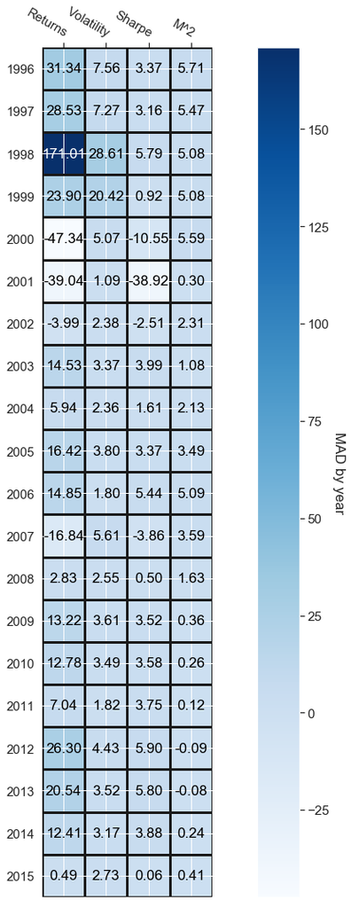

```python
fig, ax = plt.subplots(figsize=(15,15))

im, cbar = heatmap(harvest, vegetables, farmers, ax=ax,
                   cmap="Blues", cbarlabel="MAD by year")
texts = annotate_heatmap(im)

fig.tight_layout()
plt.show()
```

#### The previous plot show all the perfomance measures together through the years. It is a good way to be able to compare the different measures according to the corresponding year.

> Variables to use:
> 1. Return
> 2. Volatility
> 3. Sharpe index
> 4. $ M^2$ index

> *Note: All data is annualized*